# Singlehood SHARE: Analyses Overview

Author

Michael Krämer

## 1 Load packages

```r
library(renv)
library(tidyverse)
library(broom)
library(labelled)
library(psych)
library(quest) # for POMP scores
library(GPArotation)
library(specr)
library(lme4)
library(lmerTest)
library(furrr)
library(knitr)
library(performance)
library(Hmisc)
library(corrplot)
```

## 2 Load cleaned data

```r
base::load("data/01_cleaned/df_singles.rda")
df_singles <- data_prepped
```

## 3 More data cleaning

```r
df_singles <- df_singles %>% group_by(mergeid) %>% mutate(pid = cur_group_id()) %>% ungroup() %>%
  mutate(age_c = age - mean(age, na.rm=T))

# rename for easier to interpret var names
df_singles <- df_singles %>%
  rename(extraversion = bfi10_extra, agreeableness = bfi10_agree, conscientiousness = bfi10_consc,
         neuroticism = bfi10_neuro, openness = bfi10_open,
         ever_partnered = everlat, ever_cohabitating = evercohab, ever_married = evermarried,
         life_satisfaction = ac012_, quality_of_life = casp, income = thinc2)
# code education
df_singles <- df_singles %>%
  mutate(education = case_when(
    isced1997_r == 1 ~ "ISCED_1",
    isced1997_r == 2 ~ "ISCED_2",
    isced1997_r == 3 ~ "ISCED_3",
    isced1997_r == 4 ~ "ISCED_4",
    isced1997_r == 5 ~ "ISCED_5",
    isced1997_r == 6 ~ "ISCED_6",
    isced1997_r %in% c(0, 95, 96) ~ "other/none",
    .default = NA_character_
  )) %>% # also dummy coding (1 = reference category)
  mutate(isced_2 = ifelse(!is.na(education), ifelse(education=="ISCED_2", 1, 0), NA),
         isced_3 = ifelse(!is.na(education), ifelse(education=="ISCED_3", 1, 0), NA),
         isced_4 = ifelse(!is.na(education), ifelse(education=="ISCED_4", 1, 0), NA),
         isced_5 = ifelse(!is.na(education), ifelse(education=="ISCED_5", 1, 0), NA),
         isced_6 = ifelse(!is.na(education), ifelse(education=="ISCED_6", 1, 0), NA),
         isced_other = ifelse(!is.na(education), ifelse(education=="other/none", 1, 0), NA)) %>%
  mutate(income_z = scale(income)) # z-standardize income

# switch 0/1 dummy coding for predictors
df_singles <- df_singles %>%
  mutate(never_partnered = if_else(ever_partnered==1, 0, ifelse(ever_partnered==0, 1, NA)),
         never_cohabitating = if_else(ever_cohabitating==1, 0, ifelse(ever_cohabitating==0, 1, NA)),
         never_married = if_else(ever_married==1, 0, ifelse(ever_married==0, 1, NA)))
```

### 3.1 Reliability CASP-12

```r
# recode all CASP-items so that higher values relate to better well-being. right now it is:
# 1 [Often]
# 2 [Sometimes]
# 3 [Rarely]
# 4 [Never]
df_singles <- df_singles %>%
  mutate(across(starts_with("casp"), ~ max(.x, na.rm=T) - .x + 1))

# count missings
df_singles <- df_singles %>%
  rowwise %>%
  mutate(na_casp = sum(is.na(across(starts_with("casp"))))) %>%
  ungroup()

# Cronbach's alpha
alpha_casp <- df_singles %>%
  dplyr::select(starts_with("casp")) %>%
  psych::alpha(check.keys = TRUE)
alpha_casp$total
```

```
 raw_alpha std.alpha   G6(smc) average_r      S/N          ase     mean
 0.8295807 0.8361035 0.8462401 0.2983036 5.101412 0.0008981087 3.056545
        sd  median_r
 0.5467375 0.2921106
```

```r
# Omega
omega_casp <- df_singles %>%
  dplyr::select(starts_with("casp")) %>%
  psych::omega(m = ., keys = alpha_casp$keys, plot = FALSE, nfactors=4)
omega_casp$omega_h
```

```
[1] 0.7100251
```

```r
omega_casp$omega.tot
```

```
[1] 0.8750715
```

```r
# add scored variable
df_singles$casp <- df_singles %>%
  select(starts_with("casp")) %>%
  psych::reverse.code(keys=alpha_casp$keys[[1]], items = .) %>%
  rowSums(na.rm=T)

df_singles <- df_singles %>%
  mutate(casp_all = ifelse(na_casp>0, NA, casp), # same as in generated var: score is NA if one or more items are NA
         casp_alt = ifelse(na_casp>4, NA, casp)) # alternative: score is NA if more than 4 items are NA
summary(df_singles$casp_all) # same as generated variable
```

```
   Min. 1st Qu.  Median    Mean 3rd Qu.    Max.    NA's
  12.00   32.00   37.00   36.84   42.00   48.00    6607
```

```r
summary(df_singles$quality_of_life)
```

```
   Min. 1st Qu.  Median    Mean 3rd Qu.    Max.    NA's
  12.00   32.00   37.00   36.84   42.00   48.00    6607
```

```r
summary(df_singles$casp_alt) # 4111 less NA!
```

```
   Min. 1st Qu.  Median    Mean 3rd Qu.    Max.    NA's
   9.00   32.00   37.00   36.51   42.00   48.00    2496
```

### 3.2 Winsorize variables

```r
# winsorizing of outliers (code from Yannick Roos):
# calculate means and standard deviations
means <- sapply(df_singles[, c("extraversion", "agreeableness", "conscientiousness", "neuroticism", "openness",
                               "life_satisfaction", "quality_of_life", "casp_alt")], mean, na.rm = TRUE)
sds <- sapply(df_singles[, c("extraversion", "agreeableness", "conscientiousness", "neuroticism", "openness",
                             "life_satisfaction", "quality_of_life", "casp_alt")], sd, na.rm = TRUE)

# combine results into a data frame
result_df <- data.frame(variable = names(means), mean = round(means,digits = 2), sd = round(sds,digits = 2))

# detect outliers and winsorize as necessary
for (col_name in c("extraversion", "agreeableness", "conscientiousness", "neuroticism", "openness",
                    "life_satisfaction", "quality_of_life", "casp_alt")) {
  # detect outliers
  outlier_indices <- which(df_singles[, col_name] < means[col_name] - 3 * sds[col_name] |
                             df_singles[, col_name] > means[col_name] + 3 * sds[col_name])

  # winsorize if necessary
  if (length(outlier_indices) > 0) {
    print(paste(col_name, "has", length(outlier_indices),"outlier(s)"))
    # create a new column with the winsorized values
    winsorized_col_name <- paste0(col_name, "_w")
    df_singles[winsorized_col_name] <- df_singles[, col_name]
    df_singles[winsorized_col_name][df_singles[winsorized_col_name] < means[col_name] - 3 * sds[col_name]] <- means[col_name] - 3 * sds[col_name]
    df_singles[winsorized_col_name][df_singles[winsorized_col_name] > means[col_name] + 3 * sds[col_name]] <- means[col_name] + 3 * sds[col_name]
  }
}
```

```
[1] "agreeableness has 317 outlier(s)"
[1] "conscientiousness has 457 outlier(s)"
[1] "life_satisfaction has 770 outlier(s)"
[1] "quality_of_life has 201 outlier(s)"
[1] "casp_alt has 218 outlier(s)"
```

### 3.3 Rescale variables

```r
# POMP scores for well-being (because scale is very different across the two!)
df_singles <- df_singles %>%
  mutate(life_satisfaction_p = quest::pomp(life_satisfaction_w, mini=0, maxi=10, relative = FALSE, unit = 1),
         quality_of_life_p = quest::pomp(quality_of_life_w, mini=12, maxi=48, relative = FALSE, unit = 1),
         casp_alt_p = quest::pomp(casp_alt, mini=12, maxi=48, relative = FALSE, unit = 1))
```

### 3.4 Merge country-level data

```r
df_singles <- df_singles %>% group_by(mergeid) %>% mutate(pid = cur_group_id()) %>% ungroup() %>%
  mutate(country_str = as.character(haven::as_factor(country)))
df_singles$country_str <- sub(" ", "_", df_singles$country_str) # for Czech Republic

df_country_level <- read_csv2("country_data.csv") %>% rename(country_str = Country)

df_singles <- df_singles %>% left_join(df_country_level)

df_singles <- df_singles %>%
  rename(religiosity = Religiosity, gender_ratio = `Gender_ratio(maleper100female)`,
         singles_proportion = Total_Singlehood_Ratio) %>%
  mutate(religiosity_z = scale(religiosity), # z-standardize
         gender_ratio_z = scale(gender_ratio),
         singles_proportion_z = scale(singles_proportion))

# labelled variable types sometimes cause problems donwstream -> convert to numeric
df_singles <- df_singles %>% mutate_at(c("extraversion", "agreeableness_w", "conscientiousness_w", "neuroticism", "openness",
                                         "life_satisfaction_p", "quality_of_life_p"), as.numeric)
```

## 4 Descriptives

### 4.1 Sample size

*How many participants do we have in total / in each group (never married/ never cohabitating/ never partnered)?*

```r
# for all participants
df_singles %>% filter(!is.na(never_partnered) | !is.na(never_cohabitating) | !is.na(never_married)) %>% tally()
```

```
# A tibble: 1 × 1
      n
  <int>
1 77064
```

```r
# never partnered (0 = no, 1 = yes)
df_singles %>% group_by(never_partnered) %>% tally()
```

```
# A tibble: 3 × 2
  never_partnered     n
            <dbl> <int>
1               0 74675
2               1  2364
3              NA   163
```

```r
# never cohabitating (0 = no, 1 = yes)
df_singles %>% group_by(never_cohabitating) %>% tally()
```

```
# A tibble: 3 × 2
  never_cohabitating     n
               <dbl> <int>
1                  0 74111
2                  1  2935
3                 NA   156
```

```r
# never partnered (0 = no, 1 = yes)
df_singles %>% group_by(never_married) %>% tally()
```

```
# A tibble: 3 × 2
  never_married     n
          <dbl> <int>
1             0 72082
2             1  4941
3            NA   179
```

### 4.2 Age

*How old are they?*

```r
# for all participants
df_singles %>% filter(!is.na(never_partnered) | !is.na(never_cohabitating) | !is.na(never_married)) %>%
  summarise(mean_age = mean(age, na.rm=T), sd_age = sd(age, na.rm=T),
            min_age = min(age, na.rm=T), max_age = max(age, na.rm=T))
```

```
# A tibble: 1 × 4
  mean_age sd_age min_age max_age
     <dbl>  <dbl>   <dbl>   <dbl>
1     68.5   10.0      22     105
```

```r
# never partnered (0 = no, 1 = yes)
df_singles %>% group_by(never_partnered) %>%
  summarise(mean_age = mean(age, na.rm=T), sd_age = sd(age, na.rm=T),
            min_age = min(age, na.rm=T), max_age = max(age, na.rm=T))
```

```
# A tibble: 3 × 5
  never_partnered mean_age sd_age min_age max_age
            <dbl>    <dbl>  <dbl>   <dbl>   <dbl>
1               0     68.5   10.0      27     105
2               1     67.7   10.3      22      99
3              NA     68.2   11.6      43      97
```

```r
# never cohabitating (0 = no, 1 = yes)
df_singles %>% group_by(never_cohabitating) %>%
  summarise(mean_age = mean(age, na.rm=T), sd_age = sd(age, na.rm=T),
            min_age = min(age, na.rm=T), max_age = max(age, na.rm=T))
```

```
# A tibble: 3 × 5
  never_cohabitating mean_age sd_age min_age max_age
               <dbl>    <dbl>  <dbl>   <dbl>   <dbl>
1                  0     68.5   10.0      27     105
2                  1     67.4   10.2      22      99
3                 NA     67.9   11.6      43      96
```

```r
# never partnered (0 = no, 1 = yes)
df_singles %>% group_by(never_married) %>%
  summarise(mean_age = mean(age, na.rm=T), sd_age = sd(age, na.rm=T),
            min_age = min(age, na.rm=T), max_age = max(age, na.rm=T))
```

```
# A tibble: 3 × 5
  never_married mean_age sd_age min_age max_age
          <dbl>    <dbl>  <dbl>   <dbl>   <dbl>
1             0     68.7  10.0       27     105
2             1     65.4   9.99      22      99
3            NA     68.8  11.3       43      96
```

What explains the low minimum age? -> Younger partners of older household heads!

Only look at those under 50: How many?

```r
# for all participants
df_singles %>% filter(age<50 & (!is.na(never_partnered) | !is.na(never_cohabitating) | !is.na(never_married))) %>%
  summarise(n = n(), mean_age = mean(age, na.rm=T), sd_age = sd(age, na.rm=T),
            min_age = min(age, na.rm=T), max_age = max(age, na.rm=T))
```

```
# A tibble: 1 × 5
      n mean_age sd_age min_age max_age
  <int>    <dbl>  <dbl>   <dbl>   <dbl>
1   822     45.8   3.77      22      49
```

```r
# never partnered (0 = no, 1 = yes)
df_singles %>% filter(age<50) %>% group_by(never_partnered) %>%
  summarise(n = n(), mean_age = mean(age, na.rm=T), sd_age = sd(age, na.rm=T),
            min_age = min(age, na.rm=T), max_age = max(age, na.rm=T))
```

```
# A tibble: 3 × 6
  never_partnered     n mean_age sd_age min_age max_age
            <dbl> <int>    <dbl>  <dbl>   <dbl>   <dbl>
1               0   807     45.9   3.67      27      49
2               1    15     42.1   6.58      22      47
3              NA     3     45     1.73      43      46
```

```r
# never cohabitating (0 = no, 1 = yes)
df_singles %>% filter(age<50) %>% group_by(never_cohabitating) %>%
  summarise(n = n(), mean_age = mean(age, na.rm=T), sd_age = sd(age, na.rm=T),
            min_age = min(age, na.rm=T), max_age = max(age, na.rm=T))
```

```
# A tibble: 3 × 6
  never_cohabitating     n mean_age sd_age min_age max_age
               <dbl> <int>    <dbl>  <dbl>   <dbl>   <dbl>
1                  0   804     45.9   3.66      27      49
2                  1    18     42.8   6.40      22      49
3                 NA     3     45     1.73      43      46
```

```r
# never partnered (0 = no, 1 = yes)
df_singles %>% filter(age<50) %>% group_by(never_married) %>%
  summarise(n = n(), mean_age = mean(age, na.rm=T), sd_age = sd(age, na.rm=T),
            min_age = min(age, na.rm=T), max_age = max(age, na.rm=T))
```

```
# A tibble: 3 × 6
  never_married     n mean_age sd_age min_age max_age
          <dbl> <int>    <dbl>  <dbl>   <dbl>   <dbl>
1             0   726     46.1   3.45      27      49
2             1    96     43.5   5.07      22      49
3            NA     3     45     1.73      43      46
```

### 4.3 Gender

*Gender ratios in each group?*

```r
# for all participants
df_singles %>% filter(!is.na(never_partnered) | !is.na(never_cohabitating) | !is.na(never_married)) %>%
  group_by(female) %>% tally()
```

```
# A tibble: 2 × 2
  female     n
   <dbl> <int>
1      0 33057
2      1 44007
```

```r
df_singles %>% filter(!is.na(never_partnered) | !is.na(never_cohabitating) | !is.na(never_married)) %>%
  summarise(n = n(), prop_female = mean(female, na.rm=T)*100)
```

```
# A tibble: 1 × 2
      n prop_female
  <int>       <dbl>
1 77064        57.1
```

```r
# never partnered (0 = no, 1 = yes)
df_singles %>% group_by(never_partnered, female) %>% tally()
```

```
# A tibble: 6 × 3
# Groups:   never_partnered [3]
  never_partnered female     n
            <dbl>  <dbl> <int>
1               0      0 31845
2               0      1 42830
3               1      0  1202
4               1      1  1162
5              NA      0    74
6              NA      1    89
```

```r
df_singles %>% group_by(never_partnered) %>% summarise(n = n(), prop_female = mean(female, na.rm=T)*100)
```

```
# A tibble: 3 × 3
  never_partnered     n prop_female
            <dbl> <int>       <dbl>
1               0 74675        57.4
2               1  2364        49.2
3              NA   163        54.6
```

```r
# never cohabitating (0 = no, 1 = yes)
df_singles %>% group_by(never_cohabitating, female) %>% tally()
```

```
# A tibble: 6 × 3
# Groups:   never_cohabitating [3]
  never_cohabitating female     n
               <dbl>  <dbl> <int>
1                  0      0 31593
2                  0      1 42518
3                  1      0  1460
4                  1      1  1475
5                 NA      0    68
6                 NA      1    88
```

```r
df_singles %>% group_by(never_cohabitating) %>% summarise(n = n(), prop_female = mean(female, na.rm=T)*100)
```

```
# A tibble: 3 × 3
  never_cohabitating     n prop_female
               <dbl> <int>       <dbl>
1                  0 74111        57.4
2                  1  2935        50.3
3                 NA   156        56.4
```

```r
# never partnered (0 = no, 1 = yes)
df_singles %>% group_by(never_married, female) %>% tally()
```

```
# A tibble: 6 × 3
# Groups:   never_married [3]
  never_married female     n
          <dbl>  <dbl> <int>
1             0      0 30635
2             0      1 41447
3             1      0  2408
4             1      1  2533
5            NA      0    78
6            NA      1   101
```

```r
df_singles %>% group_by(never_married) %>% summarise(n = n(), prop_female = mean(female, na.rm=T)*100)
```

```
# A tibble: 3 × 3
  never_married     n prop_female
          <dbl> <int>       <dbl>
1             0 72082        57.5
2             1  4941        51.3
3            NA   179        56.4
```

### 4.4 Across countries

*How many people from each country?*

```r
# the last three columns show the proportions of singlehood (across the three different operationalizations)
df_singles %>% group_by(country_str) %>% summarise(n = n(), prop_female = mean(female, na.rm=T)*100,
                                                   prop_nev_part = mean(never_partnered, na.rm=T)*100,
                                                   prop_nev_cohab = mean(never_cohabitating, na.rm=T)*100,
                                                   prop_nev_marr = mean(never_married, na.rm=T)*100) %>%
  print(n=Inf)
```

```
# A tibble: 27 × 6
   country_str        n prop_female prop_nev_part prop_nev_cohab prop_nev_marr
   <chr>          <int>       <dbl>         <dbl>          <dbl>         <dbl>
 1 Austria         3176        59.2          2.37           3.79          7.29
 2 Belgium         4900        55.7          2.80           3.62          6.93
 3 Bulgaria        1998        58.2          2.21           3.36          4.66
 4 Croatia         2408        55.8          2.54           3.12          4.16
 5 Cyprus          1233        59.9          1.63           1.79          1.95
 6 Czech_Republic  4212        60.1          1.40           1.81          3.16
 7 Denmark         3246        54.4          1.51           1.94          6.85
 8 Estonia         5115        61.4          2.76           3.23          8.41
 9 Finland         2007        54.1          2.14           3.44          9.73
10 France          3331        58.3          2.89           4.12          8.27
11 Germany         3820        53.2          1.60           2.60          5.15
12 Greece          3070        57.8          2.49           4.05          5.06
13 Hungary         1538        60.5          1.44           1.37          2.42
14 Israel          2131        57.5          4.87           5.11          4.87
15 Italy           4568        55.1          4.19           5.37          6.92
16 Latvia          1734        63.6          3.87           4.05          6.87
17 Lithuania       2035        64.1          2.76           3.25          4.63
18 Luxembourg      1250        54.2          3.45           4.25          5.29
19 Malta           1261        56.2         14.8           15.9          16.9
20 Poland          4703        55.5          2.94           3.45          4.45
21 Portugal        1282        55.9          4.46           4.85          6.42
22 Romania         2114        57.5          2.46           2.51          3.93
23 Slovakia        2077        54.2          4.24           5.06          5.97
24 Slovenia        3691        58.1          4.09           4.53          7.65
25 Spain           4704        56.0          4.22           4.88          6.63
26 Sweden          3196        54.0          2.04           2.76          9.52
27 Switzerland     2402        54.8          3.55           4.63          8.64
```

Something weird is going on in Malta!

### 4.5 Correlation matrix

```r
vars = df_singles[, c("female", "age", "life_satisfaction_w", "quality_of_life_w",
                      "agreeableness_w", "conscientiousness_w", "extraversion", "neuroticism", "openness",
                      "never_partnered", "never_cohabitating", "never_married")] %>% mutate_all(list(~ as.numeric(.)))
cormat <- Hmisc::rcorr(as.matrix(vars), type="pearson") # uses pairwise complete pairs
cormat <- cormat$r

rownames(cormat) <- c("Gender (1 = f.)", "Age","Life Satisfaction" , "Quality of Life",
                      "Agreeableness", "Conscientiousness", "Extraversion", "Neuroticism", "Openness",
                      "Never partnered", "Never cohabitating", "Never married")
colnames(cormat) <- c("Gender (1 = f.)", "Age","Life Satisfaction" , "Quality of Life",
                      "Agreeableness", "Conscientiousness", "Extraversion", "Neuroticism", "Openness",
                      "Never partnered", "Never cohabitating", "Never married")

round(cormat, 2)
```

```
                   Gender (1 = f.)   Age Life Satisfaction Quality of Life
Gender (1 = f.)               1.00 -0.02             -0.05           -0.07
Age                          -0.02  1.00             -0.05           -0.19
Life Satisfaction            -0.05 -0.05              1.00            0.59
Quality of Life              -0.07 -0.19              0.59            1.00
Agreeableness                 0.05  0.05              0.12            0.16
Conscientiousness             0.05 -0.01              0.14            0.24
Extraversion                  0.02 -0.04              0.17            0.25
Neuroticism                   0.12 -0.01             -0.26           -0.37
Openness                      0.04 -0.07              0.10            0.17
Never partnered              -0.03 -0.01             -0.04           -0.04
Never cohabitating           -0.03 -0.02             -0.05           -0.03
Never married                -0.03 -0.08             -0.04           -0.02
                   Agreeableness Conscientiousness Extraversion Neuroticism
Gender (1 = f.)             0.05              0.05         0.02        0.12
Age                         0.05             -0.01        -0.04       -0.01
Life Satisfaction           0.12              0.14         0.17       -0.26
Quality of Life             0.16              0.24         0.25       -0.37
Agreeableness               1.00              0.16         0.17       -0.22
Conscientiousness           0.16              1.00         0.18       -0.13
Extraversion                0.17              0.18         1.00       -0.21
Neuroticism                -0.22             -0.13        -0.21        1.00
Openness                    0.02              0.09         0.13       -0.07
Never partnered            -0.01             -0.02        -0.04        0.00
Never cohabitating         -0.01             -0.03        -0.05        0.00
Never married               0.00             -0.04        -0.04       -0.01
                   Openness Never partnered Never cohabitating Never married
Gender (1 = f.)        0.04           -0.03              -0.03         -0.03
Age                   -0.07           -0.01              -0.02         -0.08
Life Satisfaction      0.10           -0.04              -0.05         -0.04
Quality of Life        0.17           -0.04              -0.03         -0.02
Agreeableness          0.02           -0.01              -0.01          0.00
Conscientiousness      0.09           -0.02              -0.03         -0.04
Extraversion           0.13           -0.04              -0.05         -0.04
Neuroticism           -0.07            0.00               0.00         -0.01
Openness               1.00           -0.02              -0.02          0.00
Never partnered       -0.02            1.00               0.90          0.68
Never cohabitating    -0.02            0.90               1.00          0.76
Never married          0.00            0.68               0.76          1.00
```

Plot: Correlation matrix

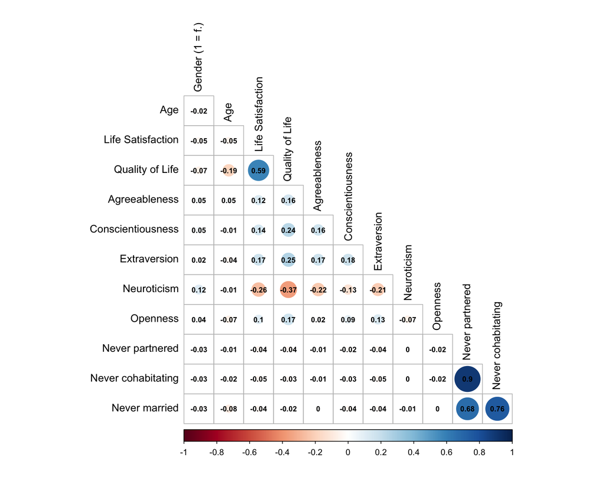

```r
corrplot::corrplot(cormat, type = "lower", order = "original", tl.col = "black",
                   addCoef.col ='black', number.cex = 0.7, diag = F) # also add numbers
```

## 5 Confirmatory results

### 5.1 Specification curve analyses (SCA)

Run SCA:

```r
specifications_b5 <- crossing(
  vec_outcome = c("extraversion", "agreeableness_w", "conscientiousness_w", "neuroticism", "openness"),
  vec_predictor = c("never_partnered", "never_cohabitating", "never_married"),
  vec_controls = c("none", "age", "gender", "income", "education", "religiosity", "gender_ratio", "singles_proportion", "all")) %>%
  mutate(specnr = row_number()) %>%
  mutate(spec_name = paste0("outcome=", vec_outcome, ", predictor=", vec_predictor,
                            ", controls=", vec_controls))

# custom function
# random intercept model:
lmer_ri_1 <- function(formula, data,...) {
  require(lme4)
  require(broom.mixed)
  formula <- paste(formula, "+ (1|country_str)")
  lme4::lmer(formula, data)
}
lmer_ri_2 <- function(formula, data,...) {
  require(lmerTest)
  require(broom.mixed)
  formula <- paste(formula, "+ (1|country_str)")
  lmerTest::lmer(formula, data)
}

# Including random slopes (country as grouping variable -> as preregistered)
lmer_rs_1 <- function(formula, data,...) {
  require(lme4)
  require(broom.mixed)
  slopevars <- word(unlist(strsplit(formula, " ~ "))[2], 1, sep=fixed(" + ")) # only 1 random slope (of 'group' var)
  formula <- paste0(formula, "+ (1 + ", slopevars, "|country_str)" )
  lme4::lmer(formula, data, control=lmerControl(optimizer="bobyqa",
                                                optCtrl=list(maxfun=2e5)))
}
lmer_rs_2 <- function(formula, data,...) {
  require(lmerTest)
  require(broom.mixed)
  slopevars <- word(unlist(strsplit(formula, " ~ "))[2], 1, sep=fixed(" + "))
  formula <- paste0(formula, "+ (1 + ", slopevars, "|country_str)" )
  lmerTest::lmer(formula, data, control=lmerControl(optimizer="bobyqa",
                                                optCtrl=list(maxfun=2e5)))
}

# personality
# Setup Specifications
specs_b5 <- specr::setup(data = df_singles,
                  y = c("extraversion", "agreeableness_w", "conscientiousness_w", "neuroticism", "openness"),
                  x = c("never_partnered", "never_cohabitating", "never_married"),
                  controls = c("age_c", "female", "income_z", "education",
                               "religiosity_z", "gender_ratio_z", "singles_proportion_z"),
                  simplify = T, # not all combinations of covars
                  model = c("lmer_rs_1"))

# identical, but with p-values pls
specs_b5_p <- specr::setup(data = df_singles,
                  y = c("extraversion", "agreeableness_w", "conscientiousness_w", "neuroticism", "openness"),
                  x = c("never_partnered", "never_cohabitating", "never_married"),
                  controls = c("age_c", "female", "income_z", "education",
                               "religiosity_z", "gender_ratio_z", "singles_proportion_z"),
                  simplify = T, # not all combinations of covars
                  model = c("lmer_rs_2"))

# Run Specification Curve Analysis
#opts <- furrr_options( # for parallelization (using multiple cores)
#  globals = list(lmer_rs_1 = lmer_rs_1)
#)
#plan(strategy = multisession, workers = 6)
sca_b5 <- specr(specs_b5)
                #.options = opts,   # Pass opts to specr
                #.progress = TRUE)
sca_b5_p <- specr(specs_b5_p) # run again (for p-values)

# well-being
# Setup Specifications
specs_wb <- specr::setup(data = df_singles,
                         y = c("life_satisfaction_p", "quality_of_life_p", "casp_alt_p"),
                         x = c("never_partnered", "never_cohabitating", "never_married"),
                         controls = c("age_c", "female", "income_z", "education",
                                      "religiosity_z", "gender_ratio_z", "singles_proportion_z"),
                         simplify = T, # not all combinations of covars
                         model = c("lmer_rs_1"))

# identical, but with p-values pls
specs_wb_p <- specr::setup(data = df_singles,
                         y = c("life_satisfaction_p", "quality_of_life_p", "casp_alt_p"),
                         x = c("never_partnered", "never_cohabitating", "never_married"),
                         controls = c("age_c", "female", "income_z", "education",
                                      "religiosity_z", "gender_ratio_z", "singles_proportion_z"),
                         simplify = T, # not all combinations of covars
                         model = c("lmer_rs_2"))

# Run Specification Curve Analysis
sca_wb <- specr(specs_wb)
                #.options = opts,
                #.progress = TRUE)
sca_wb_p <- specr(specs_wb_p) # run again (for p-values)

#plan(sequential) # stop parallelization
```

SCA for personality traits:

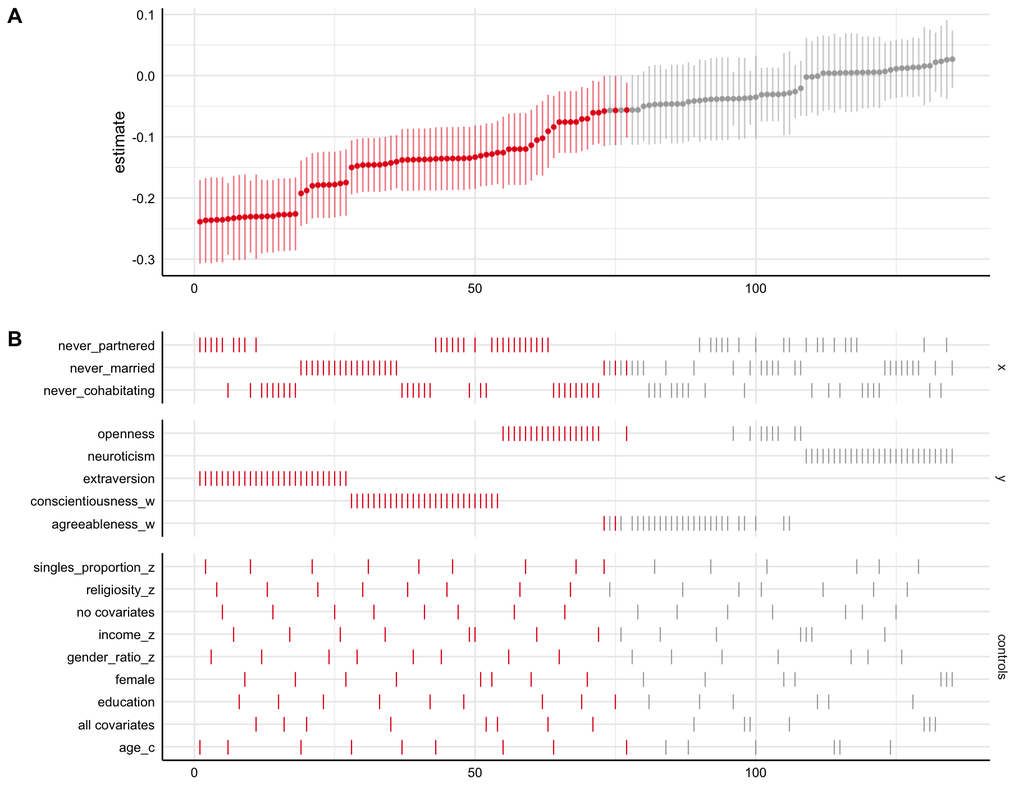

```r
# Plot Specification Curve
plot(sca_b5,
     choices = c("x", "y", "controls"))
```

Summary of entire SCA:

```r
summary(sca_b5)
```

```
Results of the specification curve analysis
-------------------
Technical details:

  Class:                          specr.object -- version: 1.0.0
  Cores used:                     1
  Duration of fitting process:    2.25 sec elapsed
  Number of specifications:       135

Descriptive summary of the specification curve:

 median  mad   min  max   q25   q75
  -0.08 0.09 -0.24 0.03 -0.14 -0.03

Descriptive summary of sample sizes:

 median   min   max
  74066 73687 74211

Head of the specification results (first 6 rows):

# A tibble: 6 × 20
  x         y     model controls subsets formula effect group estimate std.error
  <chr>     <chr> <chr> <chr>    <chr>   <glue>  <chr>  <chr>    <dbl>     <dbl>
1 never_pa… extr… lmer… no cova… all     extrav… fixed  <NA>     -0.24      0.04
2 never_pa… extr… lmer… age_c    all     extrav… fixed  <NA>     -0.24      0.03
3 never_pa… extr… lmer… female   all     extrav… fixed  <NA>     -0.23      0.04
4 never_pa… extr… lmer… income_z all     extrav… fixed  <NA>     -0.23      0.04
5 never_pa… extr… lmer… educati… all     extrav… fixed  <NA>     -0.23      0.04
6 never_pa… extr… lmer… religio… all     extrav… fixed  <NA>     -0.24      0.04
# ℹ 10 more variables: statistic <dbl>, conf.low <dbl>, conf.high <dbl>,
#   fit_nobs <dbl>, fit_sigma <dbl>, fit_logLik <dbl>, fit_AIC <dbl>,
#   fit_BIC <dbl>, fit_REMLcrit <dbl>, fit_df.residual <dbl>
```

SCA for well-being:

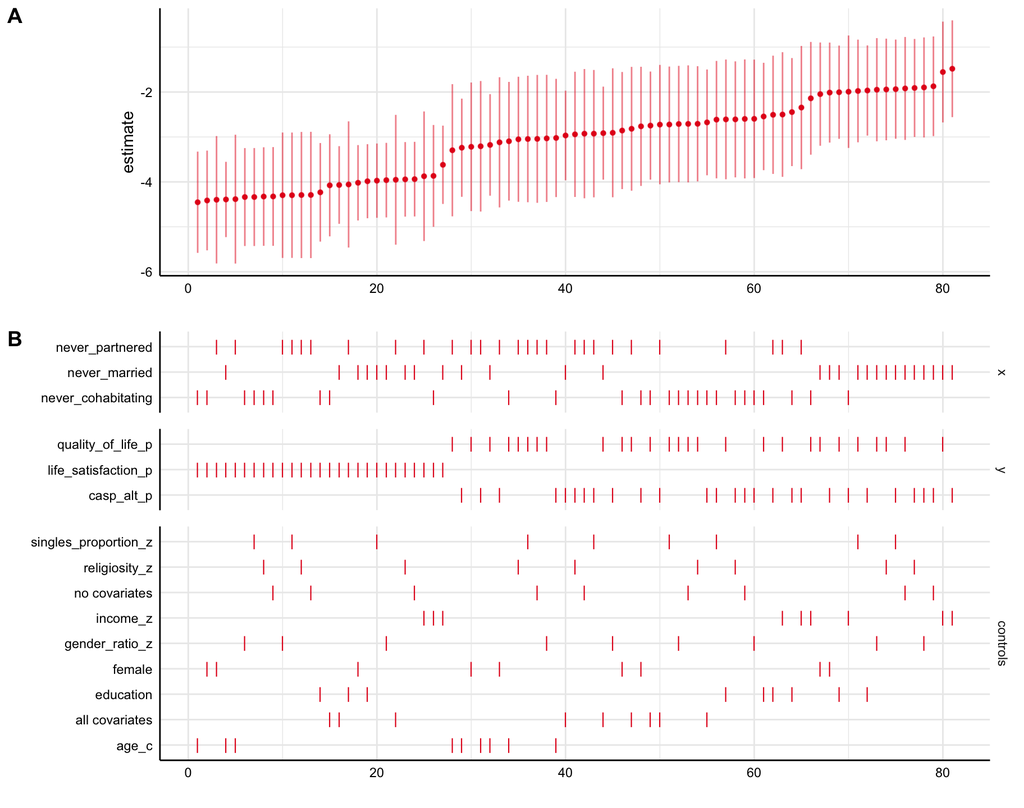

```r
# Plot Specification Curve
plot(sca_wb,
     choices = c("x", "y", "controls"))
```

Summary of entire SCA:

```r
summary(sca_wb)
```

```
Results of the specification curve analysis
-------------------
Technical details:

  Class:                          specr.object -- version: 1.0.0
  Cores used:                     1
  Duration of fitting process:    1.471 sec elapsed
  Number of specifications:       81

Descriptive summary of the specification curve:

 median  mad   min   max   q25   q75
  -2.94 1.33 -4.45 -1.48 -3.96 -2.54

Descriptive summary of sample sizes:

 median   min   max
  74504 70290 74669

Head of the specification results (first 6 rows):

# A tibble: 6 × 20
  x         y     model controls subsets formula effect group estimate std.error
  <chr>     <chr> <chr> <chr>    <chr>   <glue>  <chr>  <chr>    <dbl>     <dbl>
1 never_pa… life… lmer… no cova… all     life_s… fixed  <NA>     -4.29      0.72
2 never_pa… life… lmer… age_c    all     life_s… fixed  <NA>     -4.38      0.73
3 never_pa… life… lmer… female   all     life_s… fixed  <NA>     -4.4       0.72
4 never_pa… life… lmer… income_z all     life_s… fixed  <NA>     -3.87      0.74
5 never_pa… life… lmer… educati… all     life_s… fixed  <NA>     -4.06      0.72
6 never_pa… life… lmer… religio… all     life_s… fixed  <NA>     -4.29      0.72
# ℹ 10 more variables: statistic <dbl>, conf.low <dbl>, conf.high <dbl>,
#   fit_nobs <dbl>, fit_sigma <dbl>, fit_logLik <dbl>, fit_AIC <dbl>,
#   fit_BIC <dbl>, fit_REMLcrit <dbl>, fit_df.residual <dbl>
```

Important for interpretation: Unlike for personality, I used POMP (percentage of maximum possible) scores here to make the results comparable across the two well-being operationalizations.

### 5.2 Results summary

#### 5.2.1 Hypothesis 1: Extraversion

*Lifelong singles self-report lower levels of extraversion as compared to partnered individuals.*

All model results for extraversion:

```r
kable(sca_b5_p$data %>% filter(y=="extraversion") %>%
        select(x, controls, estimate, conf.low, conf.high, std.error, statistic, p.value, fit_nobs), digits = 3)
```

| x | controls | estimate | conf.low | conf.high | std.error | statistic | p.value | fit_nobs |
| --- | --- | --- | --- | --- | --- | --- | --- | --- |
| never_partnered | no covariates | -0.236 | -0.309 | -0.163 | 0.035 | -6.654 | 0 | 74063 |
| never_partnered | age_c | -0.239 | -0.311 | -0.167 | 0.035 | -6.846 | 0 | 74056 |
| never_partnered | female | -0.231 | -0.304 | -0.158 | 0.035 | -6.520 | 0 | 74063 |
| never_partnered | income_z | -0.233 | -0.306 | -0.160 | 0.035 | -6.599 | 0 | 74063 |
| never_partnered | education | -0.232 | -0.305 | -0.159 | 0.036 | -6.530 | 0 | 73799 |
| never_partnered | religiosity_z | -0.236 | -0.309 | -0.163 | 0.035 | -6.685 | 0 | 74063 |
| never_partnered | gender_ratio_z | -0.236 | -0.310 | -0.163 | 0.036 | -6.605 | 0 | 74063 |
| never_partnered | singles_proportion_z | -0.237 | -0.309 | -0.164 | 0.035 | -6.712 | 0 | 74063 |
| never_partnered | all covariates | -0.231 | -0.303 | -0.158 | 0.035 | -6.555 | 0 | 73792 |
| never_cohabitating | no covariates | -0.230 | -0.292 | -0.167 | 0.030 | -7.592 | 0 | 74066 |
| never_cohabitating | age_c | -0.234 | -0.296 | -0.173 | 0.030 | -7.841 | 0 | 74059 |
| never_cohabitating | female | -0.226 | -0.289 | -0.163 | 0.030 | -7.433 | 0 | 74066 |
| never_cohabitating | income_z | -0.227 | -0.289 | -0.165 | 0.030 | -7.533 | 0 | 74066 |
| never_cohabitating | education | -0.228 | -0.290 | -0.165 | 0.030 | -7.508 | 0 | 73802 |
| never_cohabitating | religiosity_z | -0.230 | -0.292 | -0.168 | 0.030 | -7.628 | 0 | 74066 |
| never_cohabitating | gender_ratio_z | -0.230 | -0.294 | -0.167 | 0.031 | -7.479 | 0 | 74066 |
| never_cohabitating | singles_proportion_z | -0.231 | -0.293 | -0.168 | 0.030 | -7.651 | 0 | 74066 |
| never_cohabitating | all covariates | -0.227 | -0.290 | -0.165 | 0.030 | -7.491 | 0 | 73795 |
| never_married | no covariates | -0.178 | -0.235 | -0.121 | 0.027 | -6.515 | 0 | 74056 |
| never_married | age_c | -0.192 | -0.249 | -0.136 | 0.027 | -7.082 | 0 | 74049 |
| never_married | female | -0.175 | -0.232 | -0.117 | 0.028 | -6.338 | 0 | 74056 |
| never_married | income_z | -0.176 | -0.233 | -0.120 | 0.027 | -6.458 | 0 | 74056 |
| never_married | education | -0.179 | -0.236 | -0.121 | 0.028 | -6.469 | 0 | 73792 |
| never_married | religiosity_z | -0.179 | -0.235 | -0.122 | 0.027 | -6.586 | 0 | 74056 |
| never_married | gender_ratio_z | -0.179 | -0.236 | -0.121 | 0.028 | -6.438 | 0 | 74056 |
| never_married | singles_proportion_z | -0.180 | -0.237 | -0.124 | 0.027 | -6.619 | 0 | 74056 |
| never_married | all covariates | -0.188 | -0.246 | -0.130 | 0.028 | -6.746 | 0 | 73785 |

Median effect size:

```r
sca_b5$data %>% filter(y=="extraversion") %>%
  group_by(x) %>%
  summarise(median_est = median(estimate), median_conf.low = median(conf.low), median_conf.high = median(conf.high))
```

```
# A tibble: 3 × 4
  x                  median_est median_conf.low median_conf.high
  <chr>                   <dbl>           <dbl>            <dbl>
1 never_cohabitating     -0.230          -0.289           -0.170
2 never_married          -0.179          -0.233           -0.125
3 never_partnered        -0.236          -0.305           -0.166
```

Negative effect for extraversion that does not depend much on the set of control variables. The effect is a bit stronger when looking at people who were never in a committed relationship or never cohabited with a partner compared to those who were never married.

#### 5.2.2 Hypothesis 2: Neuroticism

*Lifelong singles self-report higher levels of neuroticism as compared to partnered individuals.*

All model results for neuroticism:

```r
kable(sca_b5_p$data %>% filter(y=="neuroticism") %>%
        select(x, controls, estimate, conf.low, conf.high, std.error, statistic, p.value, fit_nobs), digits = 3)
```

| x | controls | estimate | conf.low | conf.high | std.error | statistic | p.value | fit_nobs |
| --- | --- | --- | --- | --- | --- | --- | --- | --- |
| never_partnered | no covariates | 0.005 | -0.063 | 0.072 | 0.033 | 0.140 | 0.890 | 74208 |
| never_partnered | age_c | 0.004 | -0.064 | 0.072 | 0.033 | 0.122 | 0.904 | 74201 |
| never_partnered | female | 0.026 | -0.042 | 0.094 | 0.033 | 0.782 | 0.442 | 74208 |
| never_partnered | income_z | -0.002 | -0.070 | 0.065 | 0.033 | -0.070 | 0.945 | 74208 |
| never_partnered | education | -0.001 | -0.069 | 0.067 | 0.033 | -0.024 | 0.981 | 73942 |
| never_partnered | religiosity_z | 0.004 | -0.061 | 0.069 | 0.032 | 0.124 | 0.902 | 74208 |
| never_partnered | gender_ratio_z | 0.005 | -0.063 | 0.073 | 0.033 | 0.144 | 0.887 | 74208 |
| never_partnered | singles_proportion_z | 0.005 | -0.062 | 0.072 | 0.032 | 0.155 | 0.878 | 74208 |
| never_partnered | all covariates | 0.016 | -0.052 | 0.083 | 0.033 | 0.477 | 0.638 | 73935 |
| never_cohabitating | no covariates | 0.005 | -0.057 | 0.067 | 0.030 | 0.174 | 0.864 | 74211 |
| never_cohabitating | age_c | 0.004 | -0.058 | 0.067 | 0.030 | 0.147 | 0.884 | 74204 |
| never_cohabitating | female | 0.023 | -0.038 | 0.085 | 0.030 | 0.787 | 0.440 | 74211 |
| never_cohabitating | income_z | -0.002 | -0.064 | 0.060 | 0.030 | -0.065 | 0.949 | 74211 |
| never_cohabitating | education | 0.004 | -0.059 | 0.067 | 0.031 | 0.130 | 0.898 | 73945 |
| never_cohabitating | religiosity_z | 0.005 | -0.055 | 0.066 | 0.029 | 0.189 | 0.852 | 74211 |
| never_cohabitating | gender_ratio_z | 0.005 | -0.057 | 0.068 | 0.030 | 0.176 | 0.862 | 74211 |
| never_cohabitating | singles_proportion_z | 0.006 | -0.056 | 0.068 | 0.030 | 0.185 | 0.855 | 74211 |
| never_cohabitating | all covariates | 0.016 | -0.046 | 0.079 | 0.030 | 0.534 | 0.599 | 73938 |
| never_married | no covariates | 0.011 | -0.039 | 0.062 | 0.024 | 0.463 | 0.648 | 74201 |
| never_married | age_c | 0.009 | -0.041 | 0.060 | 0.024 | 0.383 | 0.705 | 74194 |
| never_married | female | 0.027 | -0.023 | 0.077 | 0.024 | 1.124 | 0.274 | 74201 |
| never_married | income_z | 0.007 | -0.044 | 0.057 | 0.024 | 0.277 | 0.785 | 74201 |
| never_married | education | 0.013 | -0.039 | 0.065 | 0.025 | 0.537 | 0.597 | 73935 |
| never_married | religiosity_z | 0.012 | -0.037 | 0.062 | 0.024 | 0.522 | 0.608 | 74201 |
| never_married | gender_ratio_z | 0.012 | -0.039 | 0.063 | 0.024 | 0.499 | 0.623 | 74201 |
| never_married | singles_proportion_z | 0.014 | -0.037 | 0.064 | 0.024 | 0.558 | 0.583 | 74201 |
| never_married | all covariates | 0.022 | -0.030 | 0.074 | 0.025 | 0.878 | 0.390 | 73928 |

Median effect size:

```r
sca_b5$data %>% filter(y=="neuroticism") %>%
  group_by(x) %>%
  summarise(median_est = median(estimate), median_conf.low = median(conf.low), median_conf.high = median(conf.high))
```

```
# A tibble: 3 × 4
  x                  median_est median_conf.low median_conf.high
  <chr>                   <dbl>           <dbl>            <dbl>
1 never_cohabitating    0.00529         -0.0536           0.0641
2 never_married         0.0123          -0.0355           0.0599
3 never_partnered       0.00459         -0.0597           0.0687
```

No effect for neuroticism.

#### 5.2.3 Hypothesis 3: Conscientiousness

*Lifelong singles self-report lower levels of conscientiousness as compared to partnered individuals.*

All model results for conscientiousness:

```r
kable(sca_b5_p$data %>% filter(y=="conscientiousness_w") %>%
        select(x, controls, estimate, conf.low, conf.high, std.error, statistic, p.value, fit_nobs), digits = 3)
```

| x | controls | estimate | conf.low | conf.high | std.error | statistic | p.value | fit_nobs |
| --- | --- | --- | --- | --- | --- | --- | --- | --- |
| never_partnered | no covariates | -0.135 | -0.190 | -0.081 | 0.026 | -5.152 | 0 | 74150 |
| never_partnered | age_c | -0.136 | -0.190 | -0.082 | 0.026 | -5.174 | 0 | 74143 |
| never_partnered | female | -0.128 | -0.181 | -0.075 | 0.026 | -4.977 | 0 | 74150 |
| never_partnered | income_z | -0.133 | -0.188 | -0.079 | 0.027 | -5.021 | 0 | 74150 |
| never_partnered | education | -0.135 | -0.190 | -0.081 | 0.027 | -5.092 | 0 | 73885 |
| never_partnered | religiosity_z | -0.136 | -0.190 | -0.081 | 0.026 | -5.153 | 0 | 74150 |
| never_partnered | gender_ratio_z | -0.136 | -0.190 | -0.082 | 0.026 | -5.162 | 0 | 74150 |
| never_partnered | singles_proportion_z | -0.135 | -0.190 | -0.081 | 0.026 | -5.152 | 0 | 74150 |
| never_partnered | all covariates | -0.126 | -0.180 | -0.072 | 0.026 | -4.774 | 0 | 73878 |
| never_cohabitating | no covariates | -0.137 | -0.190 | -0.084 | 0.026 | -5.314 | 0 | 74153 |
| never_cohabitating | age_c | -0.138 | -0.191 | -0.085 | 0.026 | -5.351 | 0 | 74146 |
| never_cohabitating | female | -0.131 | -0.184 | -0.079 | 0.026 | -5.139 | 0 | 74153 |
| never_cohabitating | income_z | -0.135 | -0.188 | -0.081 | 0.026 | -5.196 | 0 | 74153 |
| never_cohabitating | education | -0.137 | -0.190 | -0.083 | 0.026 | -5.260 | 0 | 73888 |
| never_cohabitating | religiosity_z | -0.138 | -0.191 | -0.084 | 0.026 | -5.318 | 0 | 74153 |
| never_cohabitating | gender_ratio_z | -0.137 | -0.191 | -0.084 | 0.026 | -5.326 | 0 | 74153 |
| never_cohabitating | singles_proportion_z | -0.137 | -0.190 | -0.084 | 0.026 | -5.315 | 0 | 74153 |
| never_cohabitating | all covariates | -0.129 | -0.183 | -0.076 | 0.026 | -4.974 | 0 | 73881 |
| never_married | no covariates | -0.146 | -0.193 | -0.099 | 0.022 | -6.514 | 0 | 74143 |
| never_married | age_c | -0.150 | -0.197 | -0.103 | 0.022 | -6.671 | 0 | 74136 |
| never_married | female | -0.141 | -0.187 | -0.094 | 0.022 | -6.334 | 0 | 74143 |
| never_married | income_z | -0.145 | -0.192 | -0.098 | 0.023 | -6.411 | 0 | 74143 |
| never_married | education | -0.146 | -0.193 | -0.099 | 0.023 | -6.459 | 0 | 73878 |
| never_married | religiosity_z | -0.146 | -0.193 | -0.099 | 0.022 | -6.513 | 0 | 74143 |
| never_married | gender_ratio_z | -0.148 | -0.195 | -0.101 | 0.023 | -6.549 | 0 | 74143 |
| never_married | singles_proportion_z | -0.146 | -0.193 | -0.099 | 0.022 | -6.514 | 0 | 74143 |
| never_married | all covariates | -0.143 | -0.190 | -0.095 | 0.023 | -6.249 | 0 | 73871 |

Median effect size:

```r
sca_b5$data %>% filter(y=="conscientiousness_w") %>%
  group_by(x) %>%
  summarise(median_est = median(estimate), median_conf.low = median(conf.low), median_conf.high = median(conf.high))
```

```
# A tibble: 3 × 4
  x                  median_est median_conf.low median_conf.high
  <chr>                   <dbl>           <dbl>            <dbl>
1 never_cohabitating     -0.137          -0.188          -0.0865
2 never_married          -0.146          -0.190          -0.102
3 never_partnered        -0.135          -0.187          -0.0839
```

Quite consistent effect for conscientiousness that is a bit smaller than the one for extraversion but is relatively similar across all the different specifications. Again, no strong influence of the covariates on the results.

#### 5.2.4 Hypothesis 4: Well-being / Life Satisfaction

*Lifelong singles self-report lower levels of life satisfaction as compared to partnered individuals.*

Important for interpretation: Unlike for personality, I used POMP (percentage of maximum possible) scores here to make the results comparable across the two well-being operationalizations.

All model results for well-being:

```r
kable(sca_wb_p$data %>% filter(y %in% c("life_satisfaction_p", "quality_of_life_p")) %>%
        select(y, x, controls, estimate, conf.low, conf.high, statistic, p.value, fit_nobs), digits = 3)
```

| y | x | controls | estimate | conf.low | conf.high | statistic | p.value | fit_nobs |
| --- | --- | --- | --- | --- | --- | --- | --- | --- |
| life_satisfaction_p | never_partnered | no covariates | -4.291 | -5.771 | -2.812 | -5.984 | 0.000 | 74511 |
| life_satisfaction_p | never_partnered | age_c | -4.384 | -5.893 | -2.875 | -5.992 | 0.000 | 74504 |
| life_satisfaction_p | never_partnered | female | -4.398 | -5.890 | -2.905 | -6.079 | 0.000 | 74511 |
| life_satisfaction_p | never_partnered | income_z | -3.875 | -5.392 | -2.357 | -5.266 | 0.000 | 74511 |
| life_satisfaction_p | never_partnered | education | -4.057 | -5.536 | -2.579 | -5.663 | 0.000 | 74243 |
| life_satisfaction_p | never_partnered | religiosity_z | -4.292 | -5.770 | -2.814 | -5.993 | 0.000 | 74511 |
| life_satisfaction_p | never_partnered | gender_ratio_z | -4.297 | -5.766 | -2.828 | -6.035 | 0.000 | 74511 |
| life_satisfaction_p | never_partnered | singles_proportion_z | -4.297 | -5.765 | -2.829 | -6.037 | 0.000 | 74511 |
| life_satisfaction_p | never_partnered | all covariates | -3.953 | -5.472 | -2.434 | -5.363 | 0.000 | 74236 |
| quality_of_life_p | never_partnered | no covariates | -3.043 | -4.536 | -1.549 | -4.190 | 0.000 | 70557 |
| quality_of_life_p | never_partnered | age_c | -3.296 | -4.840 | -1.752 | -4.392 | 0.000 | 70550 |
| quality_of_life_p | never_partnered | female | -3.219 | -4.721 | -1.717 | -4.410 | 0.000 | 70557 |
| quality_of_life_p | never_partnered | income_z | -2.501 | -3.955 | -1.047 | -3.534 | 0.002 | 70557 |
| quality_of_life_p | never_partnered | education | -2.609 | -4.008 | -1.211 | -3.837 | 0.001 | 70303 |
| quality_of_life_p | never_partnered | religiosity_z | -3.052 | -4.512 | -1.592 | -4.298 | 0.000 | 70557 |
| quality_of_life_p | never_partnered | gender_ratio_z | -3.032 | -4.517 | -1.547 | -4.201 | 0.000 | 70557 |
| quality_of_life_p | never_partnered | singles_proportion_z | -3.045 | -4.522 | -1.569 | -4.240 | 0.000 | 70557 |
| quality_of_life_p | never_partnered | all covariates | -2.818 | -4.265 | -1.371 | -4.009 | 0.000 | 70296 |
| life_satisfaction_p | never_cohabitating | no covariates | -4.325 | -5.484 | -3.165 | -7.714 | 0.000 | 74516 |
| life_satisfaction_p | never_cohabitating | age_c | -4.453 | -5.642 | -3.265 | -7.746 | 0.000 | 74509 |
| life_satisfaction_p | never_cohabitating | female | -4.414 | -5.586 | -3.242 | -7.793 | 0.000 | 74516 |
| life_satisfaction_p | never_cohabitating | income_z | -3.867 | -5.061 | -2.673 | -6.689 | 0.000 | 74516 |
| life_satisfaction_p | never_cohabitating | education | -4.232 | -5.392 | -3.073 | -7.563 | 0.000 | 74248 |
| life_satisfaction_p | never_cohabitating | religiosity_z | -4.327 | -5.484 | -3.169 | -7.732 | 0.000 | 74516 |
| life_satisfaction_p | never_cohabitating | gender_ratio_z | -4.338 | -5.488 | -3.187 | -7.801 | 0.000 | 74516 |
| life_satisfaction_p | never_cohabitating | singles_proportion_z | -4.337 | -5.488 | -3.187 | -7.796 | 0.000 | 74516 |
| life_satisfaction_p | never_cohabitating | all covariates | -4.077 | -5.274 | -2.879 | -7.033 | 0.000 | 74241 |
| quality_of_life_p | never_cohabitating | no covariates | -2.709 | -4.074 | -1.344 | -4.077 | 0.000 | 70560 |
| quality_of_life_p | never_cohabitating | age_c | -3.096 | -4.480 | -1.711 | -4.594 | 0.000 | 70553 |
| quality_of_life_p | never_cohabitating | female | -2.857 | -4.224 | -1.491 | -4.297 | 0.000 | 70560 |
| quality_of_life_p | never_cohabitating | income_z | -2.140 | -3.453 | -0.827 | -3.343 | 0.002 | 70560 |
| quality_of_life_p | never_cohabitating | education | -2.545 | -3.797 | -1.292 | -4.173 | 0.000 | 70306 |
| quality_of_life_p | never_cohabitating | religiosity_z | -2.707 | -4.050 | -1.364 | -4.140 | 0.000 | 70560 |
| quality_of_life_p | never_cohabitating | gender_ratio_z | -2.712 | -4.068 | -1.355 | -4.107 | 0.000 | 70560 |
| quality_of_life_p | never_cohabitating | singles_proportion_z | -2.723 | -4.074 | -1.372 | -4.138 | 0.000 | 70560 |
| quality_of_life_p | never_cohabitating | all covariates | -2.747 | -4.008 | -1.487 | -4.476 | 0.000 | 70299 |
| life_satisfaction_p | never_married | no covariates | -3.939 | -4.814 | -3.064 | -9.297 | 0.000 | 74505 |
| life_satisfaction_p | never_married | age_c | -4.391 | -5.274 | -3.509 | -10.273 | 0.000 | 74498 |
| life_satisfaction_p | never_married | female | -4.020 | -4.904 | -3.136 | -9.392 | 0.000 | 74505 |
| life_satisfaction_p | never_married | income_z | -3.620 | -4.537 | -2.702 | -8.140 | 0.000 | 74505 |
| life_satisfaction_p | never_married | education | -3.986 | -4.856 | -3.115 | -9.478 | 0.000 | 74237 |
| life_satisfaction_p | never_married | religiosity_z | -3.944 | -4.818 | -3.070 | -9.316 | 0.000 | 74505 |
| life_satisfaction_p | never_married | gender_ratio_z | -3.961 | -4.836 | -3.086 | -9.354 | 0.000 | 74505 |
| life_satisfaction_p | never_married | singles_proportion_z | -3.973 | -4.844 | -3.102 | -9.417 | 0.000 | 74505 |
| life_satisfaction_p | never_married | all covariates | -4.069 | -4.981 | -3.157 | -9.226 | 0.000 | 74230 |
| quality_of_life_p | never_married | no covariates | -1.921 | -3.125 | -0.716 | -3.286 | 0.003 | 70551 |
| quality_of_life_p | never_married | age_c | -3.177 | -4.365 | -1.989 | -5.511 | 0.000 | 70544 |
| quality_of_life_p | never_married | female | -2.047 | -3.256 | -0.838 | -3.491 | 0.002 | 70551 |
| quality_of_life_p | never_married | income_z | -1.555 | -2.734 | -0.376 | -2.717 | 0.012 | 70551 |
| quality_of_life_p | never_married | education | -2.004 | -3.097 | -0.912 | -3.783 | 0.001 | 70297 |
| quality_of_life_p | never_married | religiosity_z | -1.943 | -3.133 | -0.754 | -3.367 | 0.002 | 70551 |
| quality_of_life_p | never_married | gender_ratio_z | -1.949 | -3.157 | -0.741 | -3.327 | 0.003 | 70551 |
| quality_of_life_p | never_married | singles_proportion_z | -1.977 | -3.178 | -0.775 | -3.391 | 0.002 | 70551 |
| quality_of_life_p | never_married | all covariates | -2.916 | -4.004 | -1.827 | -5.520 | 0.000 | 70290 |

Median effect size:

```r
sca_wb$data %>% filter(y %in% c("life_satisfaction_p", "quality_of_life_p")) %>%
  group_by(y, x) %>%
  summarise(median_est = median(estimate), median_conf.low = median(conf.low), median_conf.high = median(conf.high))
```

[output not shown]

```
# A tibble: 6 × 5
# Groups:   y [2]
  y                   x              median_est median_conf.low median_conf.high
  <chr>               <chr>               <dbl>           <dbl>            <dbl>
1 life_satisfaction_p never_cohabit…      -4.33           -5.42           -3.23
2 life_satisfaction_p never_married       -3.97           -4.80           -3.15
3 life_satisfaction_p never_partner…      -4.29           -5.69           -2.89
4 quality_of_life_p   never_cohabit…      -2.71           -4.01           -1.43
5 quality_of_life_p   never_married       -1.98           -3.10           -0.834
6 quality_of_life_p   never_partner…      -3.04           -4.45           -1.62
```

Alternative missingness strategy for quality of life (CASP-12 scale): use all observations with 8 or more valid item answers

```r
kable(sca_wb_p$data %>% filter(y %in% c("casp_alt_p")) %>%
        select(y, x, controls, estimate, conf.low, conf.high, statistic, p.value, fit_nobs), digits = 3)
```

| y | x | controls | estimate | conf.low | conf.high | statistic | p.value | fit_nobs |
| --- | --- | --- | --- | --- | --- | --- | --- | --- |
| casp_alt_p | never_partnered | no covariates | -2.927 | -4.436 | -1.418 | -3.988 | 0.000 | 74666 |
| casp_alt_p | never_partnered | age_c | -3.208 | -4.731 | -1.685 | -4.328 | 0.000 | 74659 |
| casp_alt_p | never_partnered | female | -3.119 | -4.640 | -1.599 | -4.220 | 0.000 | 74666 |
| casp_alt_p | never_partnered | income_z | -2.346 | -3.781 | -0.910 | -3.353 | 0.002 | 74666 |
| casp_alt_p | never_partnered | education | -2.507 | -3.886 | -1.127 | -3.734 | 0.001 | 74398 |
| casp_alt_p | never_partnered | religiosity_z | -2.942 | -4.404 | -1.480 | -4.137 | 0.000 | 74666 |
| casp_alt_p | never_partnered | gender_ratio_z | -2.907 | -4.413 | -1.402 | -3.971 | 0.001 | 74666 |
| casp_alt_p | never_partnered | singles_proportion_z | -2.927 | -4.413 | -1.440 | -4.047 | 0.000 | 74666 |
| casp_alt_p | never_partnered | all covariates | -2.725 | -4.118 | -1.332 | -4.020 | 0.000 | 74391 |
| casp_alt_p | never_cohabitating | no covariates | -2.599 | -3.987 | -1.211 | -3.847 | 0.001 | 74669 |
| casp_alt_p | never_cohabitating | age_c | -3.022 | -4.401 | -1.644 | -4.501 | 0.000 | 74662 |
| casp_alt_p | never_cohabitating | female | -2.764 | -4.154 | -1.374 | -4.085 | 0.000 | 74669 |
| casp_alt_p | never_cohabitating | income_z | -1.993 | -3.302 | -0.685 | -3.122 | 0.004 | 74669 |
| casp_alt_p | never_cohabitating | education | -2.447 | -3.707 | -1.186 | -3.988 | 0.000 | 74401 |
| casp_alt_p | never_cohabitating | religiosity_z | -2.609 | -3.961 | -1.256 | -3.960 | 0.001 | 74669 |
| casp_alt_p | never_cohabitating | gender_ratio_z | -2.597 | -3.978 | -1.215 | -3.861 | 0.001 | 74669 |
| casp_alt_p | never_cohabitating | singles_proportion_z | -2.615 | -3.984 | -1.246 | -3.922 | 0.001 | 74669 |
| casp_alt_p | never_cohabitating | all covariates | -2.676 | -3.908 | -1.444 | -4.455 | 0.000 | 74394 |
| casp_alt_p | never_married | no covariates | -1.872 | -3.037 | -0.708 | -3.310 | 0.003 | 74660 |
| casp_alt_p | never_married | age_c | -3.240 | -4.387 | -2.093 | -5.811 | 0.000 | 74653 |
| casp_alt_p | never_married | female | -2.013 | -3.182 | -0.843 | -3.544 | 0.002 | 74660 |
| casp_alt_p | never_married | income_z | -1.482 | -2.612 | -0.353 | -2.697 | 0.012 | 74660 |
| casp_alt_p | never_married | education | -1.966 | -3.021 | -0.911 | -3.839 | 0.001 | 74392 |
| casp_alt_p | never_married | religiosity_z | -1.910 | -3.054 | -0.765 | -3.433 | 0.002 | 74660 |
| casp_alt_p | never_married | gender_ratio_z | -1.898 | -3.068 | -0.728 | -3.341 | 0.003 | 74660 |
| casp_alt_p | never_married | singles_proportion_z | -1.937 | -3.096 | -0.777 | -3.438 | 0.002 | 74660 |
| casp_alt_p | never_married | all covariates | -2.967 | -4.014 | -1.920 | -5.832 | 0.000 | 74385 |

Median effect size:

```r
sca_wb$data %>% filter(y %in% c("casp_alt_p")) %>%
  group_by(y, x) %>%
  summarise(median_est = median(estimate), median_conf.low = median(conf.low), median_conf.high = median(conf.high))
```

[output not shown]

```
# A tibble: 3 × 5
# Groups:   y [1]
  y          x                  median_est median_conf.low median_conf.high
  <chr>      <chr>                   <dbl>           <dbl>            <dbl>
1 casp_alt_p never_cohabitating      -2.61           -3.91           -1.31
2 casp_alt_p never_married           -1.94           -3.01           -0.833
3 casp_alt_p never_partnered         -2.93           -4.34           -1.49
```

Very similar overall results!

## 6 Exploratory results

Differences in openness for experiences and agreeableness between lifelong singles and partnered individuals will be investigated in an exploratory manner.

### 6.1 Agreeableness

All model results:

```r
kable(sca_b5_p$data %>% filter(y=="agreeableness_w") %>%
        select(x, controls, estimate, conf.low, conf.high, std.error, statistic, p.value, fit_nobs), digits = 3)
```

| x | controls | estimate | conf.low | conf.high | std.error | statistic | p.value | fit_nobs |
| --- | --- | --- | --- | --- | --- | --- | --- | --- |
| never_partnered | no covariates | -0.038 | -0.109 | 0.033 | 0.034 | -1.098 | 0.282 | 74156 |
| never_partnered | age_c | -0.035 | -0.106 | 0.036 | 0.035 | -1.016 | 0.319 | 74149 |
| never_partnered | female | -0.030 | -0.101 | 0.041 | 0.034 | -0.874 | 0.390 | 74156 |
| never_partnered | income_z | -0.039 | -0.109 | 0.032 | 0.034 | -1.118 | 0.274 | 74156 |
| never_partnered | education | -0.041 | -0.111 | 0.030 | 0.034 | -1.183 | 0.247 | 73890 |
| never_partnered | religiosity_z | -0.038 | -0.108 | 0.033 | 0.034 | -1.097 | 0.283 | 74156 |
| never_partnered | gender_ratio_z | -0.038 | -0.109 | 0.033 | 0.034 | -1.101 | 0.281 | 74156 |
| never_partnered | singles_proportion_z | -0.039 | -0.110 | 0.032 | 0.035 | -1.122 | 0.272 | 74156 |
| never_partnered | all covariates | -0.028 | -0.100 | 0.043 | 0.035 | -0.811 | 0.424 | 73883 |
| never_cohabitating | no covariates | -0.046 | -0.114 | 0.021 | 0.033 | -1.410 | 0.171 | 74159 |
| never_cohabitating | age_c | -0.043 | -0.111 | 0.025 | 0.033 | -1.298 | 0.206 | 74152 |
| never_cohabitating | female | -0.040 | -0.108 | 0.029 | 0.033 | -1.194 | 0.243 | 74159 |
| never_cohabitating | income_z | -0.047 | -0.115 | 0.021 | 0.033 | -1.432 | 0.164 | 74159 |
| never_cohabitating | education | -0.049 | -0.116 | 0.019 | 0.033 | -1.486 | 0.150 | 73893 |
| never_cohabitating | religiosity_z | -0.046 | -0.114 | 0.021 | 0.033 | -1.408 | 0.171 | 74159 |
| never_cohabitating | gender_ratio_z | -0.046 | -0.114 | 0.021 | 0.033 | -1.413 | 0.170 | 74159 |
| never_cohabitating | singles_proportion_z | -0.047 | -0.115 | 0.021 | 0.033 | -1.431 | 0.165 | 74159 |
| never_cohabitating | all covariates | -0.037 | -0.106 | 0.032 | 0.034 | -1.101 | 0.281 | 73886 |
| never_married | no covariates | -0.056 | -0.116 | 0.004 | 0.029 | -1.931 | 0.067 | 74149 |
| never_married | age_c | -0.046 | -0.107 | 0.014 | 0.029 | -1.596 | 0.125 | 74142 |
| never_married | female | -0.050 | -0.111 | 0.011 | 0.029 | -1.710 | 0.101 | 74149 |
| never_married | income_z | -0.057 | -0.117 | 0.004 | 0.029 | -1.949 | 0.065 | 74149 |
| never_married | education | -0.057 | -0.117 | 0.003 | 0.029 | -1.967 | 0.062 | 73883 |
| never_married | religiosity_z | -0.057 | -0.117 | 0.004 | 0.029 | -1.956 | 0.064 | 74149 |
| never_married | gender_ratio_z | -0.056 | -0.117 | 0.004 | 0.029 | -1.933 | 0.067 | 74149 |
| never_married | singles_proportion_z | -0.058 | -0.119 | 0.003 | 0.029 | -1.979 | 0.061 | 74149 |
| never_married | all covariates | -0.042 | -0.104 | 0.020 | 0.030 | -1.393 | 0.178 | 73876 |

Median effect size:

```r
sca_b5$data %>% filter(y=="agreeableness_w") %>%
  group_by(x) %>%
  summarise(median_est = median(estimate), median_conf.low = median(conf.low), median_conf.high = median(conf.high))
```

```
# A tibble: 3 × 4
  x                  median_est median_conf.low median_conf.high
  <chr>                   <dbl>           <dbl>            <dbl>
1 never_cohabitating    -0.0463          -0.111         0.0181
2 never_married         -0.0562          -0.113         0.000790
3 never_partnered       -0.0378          -0.105         0.0297
```

Small effects that are not significant at *p* = .005. (These were significant in the random intercept models.)

### 6.2 Openness to experiences

All model results:

```r
kable(sca_b5_p$data %>% filter(y=="openness") %>%
        select(x, controls, estimate, conf.low, conf.high, std.error, statistic, p.value, fit_nobs), digits = 3)
```

| x | controls | estimate | conf.low | conf.high | std.error | statistic | p.value | fit_nobs |
| --- | --- | --- | --- | --- | --- | --- | --- | --- |
| never_partnered | no covariates | -0.120 | -0.182 | -0.059 | 0.030 | -4.026 | 0.001 | 73962 |
| never_partnered | age_c | -0.126 | -0.188 | -0.064 | 0.030 | -4.195 | 0.000 | 73955 |
| never_partnered | female | -0.114 | -0.175 | -0.053 | 0.030 | -3.850 | 0.001 | 73962 |
| never_partnered | income_z | -0.105 | -0.166 | -0.045 | 0.029 | -3.613 | 0.002 | 73962 |
| never_partnered | education | -0.102 | -0.166 | -0.038 | 0.031 | -3.293 | 0.003 | 73701 |
| never_partnered | religiosity_z | -0.120 | -0.182 | -0.058 | 0.030 | -4.002 | 0.001 | 73962 |
| never_partnered | gender_ratio_z | -0.120 | -0.182 | -0.059 | 0.030 | -4.040 | 0.000 | 73962 |
| never_partnered | singles_proportion_z | -0.120 | -0.182 | -0.058 | 0.030 | -4.015 | 0.001 | 73962 |
| never_partnered | all covariates | -0.091 | -0.154 | -0.028 | 0.031 | -2.983 | 0.006 | 73694 |
| never_cohabitating | no covariates | -0.076 | -0.129 | -0.022 | 0.026 | -2.950 | 0.008 | 73965 |
| never_cohabitating | age_c | -0.084 | -0.138 | -0.030 | 0.026 | -3.227 | 0.004 | 73958 |
| never_cohabitating | female | -0.071 | -0.124 | -0.017 | 0.026 | -2.746 | 0.012 | 73965 |
| never_cohabitating | income_z | -0.061 | -0.115 | -0.006 | 0.026 | -2.339 | 0.030 | 73965 |
| never_cohabitating | education | -0.071 | -0.127 | -0.015 | 0.027 | -2.654 | 0.015 | 73704 |
| never_cohabitating | religiosity_z | -0.076 | -0.130 | -0.022 | 0.026 | -2.934 | 0.008 | 73965 |
| never_cohabitating | gender_ratio_z | -0.076 | -0.129 | -0.022 | 0.026 | -2.958 | 0.008 | 73965 |
| never_cohabitating | singles_proportion_z | -0.076 | -0.129 | -0.022 | 0.026 | -2.945 | 0.008 | 73965 |
| never_cohabitating | all covariates | -0.061 | -0.116 | -0.005 | 0.027 | -2.272 | 0.033 | 73697 |
| never_married | no covariates | -0.031 | -0.077 | 0.016 | 0.022 | -1.373 | 0.183 | 73955 |
| never_married | age_c | -0.056 | -0.103 | -0.009 | 0.023 | -2.463 | 0.021 | 73948 |
| never_married | female | -0.026 | -0.072 | 0.020 | 0.022 | -1.166 | 0.255 | 73955 |
| never_married | income_z | -0.021 | -0.068 | 0.027 | 0.023 | -0.905 | 0.375 | 73955 |
| never_married | education | -0.038 | -0.084 | 0.009 | 0.022 | -1.686 | 0.107 | 73694 |
| never_married | religiosity_z | -0.031 | -0.078 | 0.015 | 0.022 | -1.395 | 0.176 | 73955 |
| never_married | gender_ratio_z | -0.031 | -0.077 | 0.016 | 0.022 | -1.371 | 0.183 | 73955 |
| never_married | singles_proportion_z | -0.031 | -0.077 | 0.016 | 0.022 | -1.373 | 0.183 | 73955 |
| never_married | all covariates | -0.036 | -0.083 | 0.010 | 0.023 | -1.613 | 0.121 | 73687 |

Median effect size:

```r
sca_b5$data %>% filter(y=="openness") %>%
  group_by(x) %>%
  summarise(median_est = median(estimate), median_conf.low = median(conf.low), median_conf.high = median(conf.high))
```

```
# A tibble: 3 × 4
  x                  median_est median_conf.low median_conf.high
  <chr>                   <dbl>           <dbl>            <dbl>
1 never_cohabitating    -0.0758         -0.126           -0.0252
2 never_married         -0.0308         -0.0747           0.0132
3 never_partnered       -0.120          -0.179           -0.0613
```

Small effect that is only consistently significant for those never in a relationship. For those who never cohabitated it depends on the included controls whether the effect is significant at *p* = .005 (just barely below that threshold when controlling for age).

### 6.3 Moderator analyses: age, income

*We will also investigate potential moderator variables for all hypothesized effects, as well as for openness for experiences and agreeableness.*

In additional analyses, using multilevel regression models, we will investigate whether the relationship between singlehood and Big 5 personality traits or life satisfaction is moderated by participants’ age or income / SES.

Run models:

```r
df_singles <- df_singles %>% rename()

# custom function
lmer_cust_int_moder = function(outcome, predictor, moderator, df, random_slope=FALSE) {

  if (random_slope==TRUE) {
    form = as.formula(paste0(outcome, " ~ 1 + ", predictor, "*", moderator,
                             " + (1 + ", predictor, " | country_str)"))
  }
  else {
    form = as.formula(paste0(outcome, " ~ 1 + ", predictor, "*", moderator, " + (1 | country_str)"))
  }
  lmerTest::lmer(form, data = get(df), control=lmerControl(optimizer="bobyqa",
                                                optCtrl=list(maxfun=2e5)))
}

outcomes <- as.list(c(rep("extraversion", 6), rep("agreeableness_w", 6), rep("conscientiousness_w", 6),
                      rep("neuroticism", 6), rep("openness", 6),
                      rep("life_satisfaction_p", 6), rep("quality_of_life_p", 6)))
predictors <- as.list(rep(c("never_partnered", "never_cohabitating", "never_married"), 14))
moderators <- as.list(rep(c("age_c", "age_c", "age_c", "income_z", "income_z", "income_z"), 7))
df_names <- rep(list("df_singles"), 42)
slopes_fr <- rep(list(TRUE), 42)
combinations <- list(outcomes=outcomes, predictors=predictors, moderators=moderators, df_names=df_names, slopes_fr=slopes_fr)

# run models
mods_expl_moder <- combinations %>%
  purrr::pmap(~with(list(...), lmer_cust_int_moder(outcomes, predictors, moderators, df_names, slopes_fr)))
names(mods_expl_moder) <- paste(unlist(outcomes), unlist(predictors), unlist(moderators), sep = "_")

# create summary df
summary_mods_expl_moder <- mods_expl_moder[[1]] %>% tidy() %>%
  filter(str_detect(term, ":")) %>%
  mutate(outcome = stringr::word(names(mods_expl_moder)[1], 1, sep = "_")) %>%
  select(outcome, term, estimate, std.error, p.value)

for (i in 2:length(mods_expl_moder)) {
  # loop over all models
  row_to_add <- mods_expl_moder[[i]] %>% tidy() %>%
  filter(str_detect(term, ":")) %>%
  mutate(outcome = stringr::word(names(mods_expl_moder)[i], 1, sep = "_")) %>%
  select(outcome, term, estimate, std.error, p.value)
  # add rows
  summary_mods_expl_moder <- bind_rows(summary_mods_expl_moder, row_to_add)
}
```

Summary of results: Extraversion

```r
summary_mods_expl_moder %>% filter(outcome=="extraversion") %>% kable(., digits = 3)
```

| outcome | term | estimate | std.error | p.value |
| --- | --- | --- | --- | --- |
| extraversion | never_partnered:age_c | 0.002 | 0.002 | 0.323 |
| extraversion | never_cohabitating:age_c | 0.002 | 0.002 | 0.326 |
| extraversion | never_married:age_c | -0.002 | 0.001 | 0.266 |
| extraversion | never_partnered:income_z | 0.028 | 0.022 | 0.210 |
| extraversion | never_cohabitating:income_z | 0.024 | 0.020 | 0.246 |
| extraversion | never_married:income_z | 0.024 | 0.015 | 0.109 |

Summary of results: Agreeableness

```r
summary_mods_expl_moder %>% filter(outcome=="agreeableness") %>% kable(., digits = 3)
```

| outcome | term | estimate | std.error | p.value |
| --- | --- | --- | --- | --- |
| agreeableness | never_partnered:age_c | 0.003 | 0.002 | 0.090 |
| agreeableness | never_cohabitating:age_c | 0.003 | 0.002 | 0.097 |
| agreeableness | never_married:age_c | 0.001 | 0.001 | 0.371 |
| agreeableness | never_partnered:income_z | -0.018 | 0.020 | 0.382 |
| agreeableness | never_cohabitating:income_z | -0.011 | 0.019 | 0.561 |
| agreeableness | never_married:income_z | 0.006 | 0.014 | 0.649 |

Summary of results: Conscientiousness

```r
summary_mods_expl_moder %>% filter(outcome=="conscientiousness") %>% kable(., digits = 3)
```

| outcome | term | estimate | std.error | p.value |
| --- | --- | --- | --- | --- |
| conscientiousness | never_partnered:age_c | 0.004 | 0.002 | 0.020 |
| conscientiousness | never_cohabitating:age_c | 0.003 | 0.002 | 0.040 |
| conscientiousness | never_married:age_c | 0.002 | 0.001 | 0.175 |
| conscientiousness | never_partnered:income_z | 0.052 | 0.019 | 0.008 |
| conscientiousness | never_cohabitating:income_z | 0.054 | 0.018 | 0.003 |
| conscientiousness | never_married:income_z | 0.030 | 0.013 | 0.021 |

Summary of results: Neuroticism

```r
summary_mods_expl_moder %>% filter(outcome=="neuroticism") %>% kable(., digits = 3)
```

| outcome | term | estimate | std.error | p.value |
| --- | --- | --- | --- | --- |
| neuroticism | never_partnered:age_c | -0.006 | 0.002 | 0.004 |
| neuroticism | never_cohabitating:age_c | -0.005 | 0.002 | 0.007 |
| neuroticism | never_married:age_c | -0.002 | 0.002 | 0.143 |
| neuroticism | never_partnered:income_z | 0.034 | 0.024 | 0.154 |
| neuroticism | never_cohabitating:income_z | 0.028 | 0.022 | 0.199 |
| neuroticism | never_married:income_z | 0.016 | 0.016 | 0.333 |

Summary of results: Openness

```r
summary_mods_expl_moder %>% filter(outcome=="openness") %>% kable(., digits = 3)
```

| outcome | term | estimate | std.error | p.value |
| --- | --- | --- | --- | --- |
| openness | never_partnered:age_c | 0.003 | 0.002 | 0.095 |
| openness | never_cohabitating:age_c | 0.002 | 0.002 | 0.349 |
| openness | never_married:age_c | -0.001 | 0.001 | 0.584 |
| openness | never_partnered:income_z | 0.000 | 0.023 | 0.997 |
| openness | never_cohabitating:income_z | 0.004 | 0.021 | 0.830 |
| openness | never_married:income_z | 0.018 | 0.015 | 0.243 |

Summary of results: Life satisfaction

```r
summary_mods_expl_moder %>% filter(outcome=="life") %>% kable(., digits = 3)
```

| outcome | term | estimate | std.error | p.value |
| --- | --- | --- | --- | --- |
| life | never_partnered:age_c | 0.160 | 0.038 | 0.000 |
| life | never_cohabitating:age_c | 0.160 | 0.034 | 0.000 |
| life | never_married:age_c | 0.101 | 0.027 | 0.000 |
| life | never_partnered:income_z | 0.061 | 0.440 | 0.891 |
| life | never_cohabitating:income_z | 0.183 | 0.399 | 0.646 |
| life | never_married:income_z | 0.284 | 0.285 | 0.318 |

Summary of results: Quality of life

```r
summary_mods_expl_moder %>% filter(outcome=="quality") %>% kable(., digits = 3)
```

| outcome | term | estimate | std.error | p.value |
| --- | --- | --- | --- | --- |
| quality | never_partnered:age_c | 0.086 | 0.037 | 0.020 |
| quality | never_cohabitating:age_c | 0.073 | 0.033 | 0.029 |
| quality | never_married:age_c | 0.043 | 0.026 | 0.099 |
| quality | never_partnered:income_z | -0.162 | 0.423 | 0.702 |
| quality | never_cohabitating:income_z | -0.175 | 0.390 | 0.654 |
| quality | never_married:income_z | 0.041 | 0.284 | 0.885 |

Only moderation that is consistently significant at *p* = .005 is for life satisfaction and age. Some inconsistent effects for conscientiousness (with the predictor “never cohabitating” and moderator income) and for neuroticism (with the predictor “never partnered” and moderator age).

### 6.4 Moderator analyses: country-level variables

*Further, although there is some evidence for cross-country or cross-cultural differences in the association between being single and life satisfaction. Thus, we investigate this association in an exploratory manner as well.*

For the geographical analyses, we will investigate differences in life satisfaction and Big 5 personality traits among singles vs. non-singles regarding the country level variables (from the countries they are currently living in) religiosity, gender ratio and single ratio (level-2 variables). More precisely, we will investigate cross-level interaction effects of these level-2 variables with ‘group’.

Run models:

```r
# custom function
lmer_cust_int_cntr = function(outcome, predictor, moderator, df, random_slope=FALSE) {

  if (random_slope==TRUE) {
    form = as.formula(paste0(outcome, " ~ 1 + ", predictor, "*", moderator,
                             " + (1 + ", predictor, " | country_str)"))
  }
  else {
    form = as.formula(paste0(outcome, " ~ 1 + ", predictor, "*", moderator, " + (1 | country_str)"))
  }
  lmerTest::lmer(form, data = get(df), control=lmerControl(optimizer="bobyqa",
                                                optCtrl=list(maxfun=2e5)))
}

outcomes <- as.list(c(rep("extraversion", 9), rep("agreeableness_w", 9), rep("conscientiousness_w", 9),
                      rep("neuroticism", 9), rep("openness", 9), rep("life_satisfaction_p", 9), rep("quality_of_life_p", 9)))
predictors <- as.list(rep(c("never_partnered", "never_cohabitating", "never_married"), 21))
moderators <- as.list(rep(c("religiosity_z", "religiosity_z", "religiosity_z",
                            "gender_ratio_z", "gender_ratio_z", "gender_ratio_z",
                            "singles_proportion_z", "singles_proportion_z", "singles_proportion_z"), 7))
df_names <- rep(list("df_singles"), 63)
slopes_fr <- rep(list(TRUE), 63)
combinations <- list(outcomes=outcomes, predictors=predictors, moderators=moderators, df_names=df_names, slopes_fr=slopes_fr)

# run models
mods_expl_cntr <- combinations %>% purrr::pmap(~with(list(...), lmer_cust_int_cntr(outcomes, predictors, moderators, df_names, slopes_fr)))
names(mods_expl_cntr) <- paste(unlist(outcomes), unlist(predictors), unlist(moderators), sep = "_")

# create summary df
summary_mods_expl_cntr <- mods_expl_cntr[[1]] %>% tidy() %>%
  filter(str_detect(term, ":")) %>%
  mutate(outcome = stringr::word(names(mods_expl_cntr)[1], 1, sep = "_")) %>%
  select(outcome, term, estimate, std.error, p.value)

for (i in 2:length(mods_expl_cntr)) {
  # loop over all models
  row_to_add <- mods_expl_cntr[[i]] %>% tidy() %>%
  filter(str_detect(term, ":")) %>%
  mutate(outcome = stringr::word(names(mods_expl_cntr)[i], 1, sep = "_")) %>%
  select(outcome, term, estimate, std.error, p.value)
  # add rows
  summary_mods_expl_cntr <- bind_rows(summary_mods_expl_cntr, row_to_add)
}
```

Summary of results: Extraversion

```r
summary_mods_expl_cntr %>% filter(outcome=="extraversion") %>% kable(., digits = 3)
```

| outcome | term | estimate | std.error | p.value |
| --- | --- | --- | --- | --- |
| extraversion | never_partnered:religiosity_z | 0.014 | 0.035 | 0.694 |
| extraversion | never_cohabitating:religiosity_z | 0.013 | 0.030 | 0.673 |
| extraversion | never_married:religiosity_z | -0.003 | 0.027 | 0.905 |
| extraversion | never_partnered:gender_ratio_z | -0.028 | 0.030 | 0.352 |
| extraversion | never_cohabitating:gender_ratio_z | -0.033 | 0.025 | 0.201 |
| extraversion | never_married:gender_ratio_z | -0.013 | 0.024 | 0.608 |
| extraversion | never_partnered:singles_proportion_z | -0.053 | 0.035 | 0.140 |
| extraversion | never_cohabitating:singles_proportion_z | -0.052 | 0.029 | 0.090 |
| extraversion | never_married:singles_proportion_z | -0.034 | 0.026 | 0.213 |

Summary of results: Agreeableness

```r
summary_mods_expl_cntr %>% filter(outcome=="agreeableness") %>% kable(., digits = 3)
```

| outcome | term | estimate | std.error | p.value |
| --- | --- | --- | --- | --- |
| agreeableness | never_partnered:religiosity_z | 0.007 | 0.034 | 0.842 |
| agreeableness | never_cohabitating:religiosity_z | -0.003 | 0.033 | 0.927 |
| agreeableness | never_married:religiosity_z | 0.019 | 0.029 | 0.507 |
| agreeableness | never_partnered:gender_ratio_z | 0.003 | 0.029 | 0.909 |
| agreeableness | never_cohabitating:gender_ratio_z | 0.003 | 0.028 | 0.927 |
| agreeableness | never_married:gender_ratio_z | -0.001 | 0.025 | 0.958 |
| agreeableness | never_partnered:singles_proportion_z | -0.039 | 0.034 | 0.265 |
| agreeableness | never_cohabitating:singles_proportion_z | -0.034 | 0.033 | 0.308 |
| agreeableness | never_married:singles_proportion_z | -0.037 | 0.028 | 0.198 |

Summary of results: Conscientiousness

```r
summary_mods_expl_cntr %>% filter(outcome=="conscientiousness") %>% kable(., digits = 3)
```

| outcome | term | estimate | std.error | p.value |
| --- | --- | --- | --- | --- |
| conscientiousness | never_partnered:religiosity_z | 0.003 | 0.026 | 0.919 |
| conscientiousness | never_cohabitating:religiosity_z | 0.014 | 0.026 | 0.592 |
| conscientiousness | never_married:religiosity_z | 0.010 | 0.022 | 0.644 |
| conscientiousness | never_partnered:gender_ratio_z | 0.001 | 0.022 | 0.980 |
| conscientiousness | never_cohabitating:gender_ratio_z | 0.004 | 0.022 | 0.872 |
| conscientiousness | never_married:gender_ratio_z | 0.022 | 0.019 | 0.271 |
| conscientiousness | never_partnered:singles_proportion_z | 0.002 | 0.027 | 0.941 |
| conscientiousness | never_cohabitating:singles_proportion_z | 0.001 | 0.026 | 0.979 |
| conscientiousness | never_married:singles_proportion_z | 0.006 | 0.022 | 0.793 |

Summary of results: Neuroticism

```r
summary_mods_expl_cntr %>% filter(outcome=="neuroticism") %>% kable(., digits = 3)
```

| outcome | term | estimate | std.error | p.value |
| --- | --- | --- | --- | --- |
| neuroticism | never_partnered:religiosity_z | -0.015 | 0.031 | 0.635 |
| neuroticism | never_cohabitating:religiosity_z | -0.013 | 0.029 | 0.665 |
| neuroticism | never_married:religiosity_z | -0.003 | 0.024 | 0.887 |
| neuroticism | never_partnered:gender_ratio_z | 0.071 | 0.022 | 0.006 |
| neuroticism | never_cohabitating:gender_ratio_z | 0.070 | 0.020 | 0.004 |
| neuroticism | never_married:gender_ratio_z | 0.043 | 0.018 | 0.032 |
| neuroticism | never_partnered:singles_proportion_z | 0.088 | 0.028 | 0.005 |
| neuroticism | never_cohabitating:singles_proportion_z | 0.069 | 0.027 | 0.017 |
| neuroticism | never_married:singles_proportion_z | 0.048 | 0.021 | 0.038 |

Summary of results: Openness

```r
summary_mods_expl_cntr %>% filter(outcome=="openness") %>% kable(., digits = 3)
```

| outcome | term | estimate | std.error | p.value |
| --- | --- | --- | --- | --- |
| openness | never_partnered:religiosity_z | 0.016 | 0.029 | 0.592 |
| openness | never_cohabitating:religiosity_z | 0.003 | 0.026 | 0.903 |
| openness | never_married:religiosity_z | -0.012 | 0.022 | 0.599 |
| openness | never_partnered:gender_ratio_z | 0.025 | 0.024 | 0.313 |
| openness | never_cohabitating:gender_ratio_z | 0.035 | 0.021 | 0.105 |
| openness | never_married:gender_ratio_z | 0.035 | 0.018 | 0.069 |
| openness | never_partnered:singles_proportion_z | -0.018 | 0.031 | 0.558 |
| openness | never_cohabitating:singles_proportion_z | -0.014 | 0.026 | 0.607 |
| openness | never_married:singles_proportion_z | 0.010 | 0.022 | 0.641 |

Summary of results: Life satisfaction

```r
summary_mods_expl_cntr %>% filter(outcome=="life") %>% kable(., digits = 3)
```

| outcome | term | estimate | std.error | p.value |
| --- | --- | --- | --- | --- |
| life | never_partnered:religiosity_z | -0.797 | 0.679 | 0.254 |
| life | never_cohabitating:religiosity_z | -0.566 | 0.533 | 0.301 |
| life | never_married:religiosity_z | -0.713 | 0.388 | 0.080 |
| life | never_partnered:gender_ratio_z | -0.867 | 0.583 | 0.151 |
| life | never_cohabitating:gender_ratio_z | -0.709 | 0.462 | 0.139 |
| life | never_married:gender_ratio_z | -0.455 | 0.362 | 0.220 |
| life | never_partnered:singles_proportion_z | -1.198 | 0.696 | 0.097 |
| life | never_cohabitating:singles_proportion_z | -0.840 | 0.548 | 0.138 |
| life | never_married:singles_proportion_z | -0.298 | 0.411 | 0.475 |

Summary of results: Quality of life

```r
summary_mods_expl_cntr %>% filter(outcome=="quality") %>% kable(., digits = 3)
```

| outcome | term | estimate | std.error | p.value |
| --- | --- | --- | --- | --- |
| quality | never_partnered:religiosity_z | -0.631 | 0.718 | 0.389 |
| quality | never_cohabitating:religiosity_z | -0.288 | 0.677 | 0.674 |
| quality | never_married:religiosity_z | -0.449 | 0.596 | 0.459 |
| quality | never_partnered:gender_ratio_z | -1.598 | 0.506 | 0.004 |
| quality | never_cohabitating:gender_ratio_z | -1.528 | 0.471 | 0.003 |
| quality | never_married:gender_ratio_z | -1.071 | 0.453 | 0.026 |
| quality | never_partnered:singles_proportion_z | -1.594 | 0.675 | 0.025 |
| quality | never_cohabitating:singles_proportion_z | -1.523 | 0.605 | 0.018 |
| quality | never_married:singles_proportion_z | -0.983 | 0.548 | 0.086 |

### 6.5 Moderator analyses: personality as a moderator of well-being effects

Analyzing the extent to which the personality differences account for the well-being differences.

Run models:

```r
# custom function
lmer_cust_int_pers = function(outcome, predictor, moderator, df, random_slope=FALSE) {

  if (random_slope==TRUE) {
    form = as.formula(paste0(outcome, " ~ 1 + ", predictor, "*", moderator,
                             " + (1 + ", predictor, " | country_str)"))
  }
  else {
    form = as.formula(paste0(outcome, " ~ 1 + ", predictor, "*", moderator, " + (1 | country_str)"))
  }
  lmerTest::lmer(form, data = get(df), control=lmerControl(optimizer="bobyqa",
                                                optCtrl=list(maxfun=2e5)))
}

outcomes <- as.list(c(rep("life_satisfaction_p", 15), rep("quality_of_life_p", 15)))
predictors <- as.list(rep(c("never_partnered", "never_cohabitating", "never_married"), 10))
moderators <- as.list(rep(c(rep("extraversion", 3), rep("agreeableness_w", 3),
                            rep("conscientiousness_w", 3), rep("neuroticism", 3),
                            rep("openness", 3)), 2))
df_names <- rep(list("df_singles"), 30)
slopes_fr <- rep(list(TRUE), 30)
combinations <- list(outcomes=outcomes, predictors=predictors, moderators=moderators, df_names=df_names, slopes_fr=slopes_fr)

# run models
mods_expl_pers <- combinations %>% purrr::pmap(~with(list(...), lmer_cust_int_pers(outcomes, predictors, moderators, df_names, slopes_fr)))
names(mods_expl_pers) <- paste(unlist(outcomes), unlist(predictors), unlist(moderators), sep = "_")

# create summary df
summary_mods_expl_pers <- mods_expl_pers[[1]] %>% tidy() %>%
  filter(str_detect(term, ":")) %>%
  mutate(outcome = stringr::word(names(mods_expl_pers)[1], 1, sep = "_")) %>%
  select(outcome, term, estimate, std.error, p.value)

for (i in 2:length(mods_expl_pers)) {
  # loop over all models
  row_to_add <- mods_expl_pers[[i]] %>% tidy() %>%
  filter(str_detect(term, ":")) %>%
  mutate(outcome = stringr::word(names(mods_expl_pers)[i], 1, sep = "_")) %>%
  select(outcome, term, estimate, std.error, p.value)
  # add rows
  summary_mods_expl_pers <- bind_rows(summary_mods_expl_pers, row_to_add)
}
```

Summary of results: Life satisfaction

```r
summary_mods_expl_pers %>% filter(outcome=="life") %>% kable(., digits = 3)
```

| outcome | term | estimate | std.error | p.value |
| --- | --- | --- | --- | --- |
| life | never_partnered:extraversion | 0.908 | 0.386 | 0.019 |
| life | never_cohabitating:extraversion | 1.113 | 0.346 | 0.001 |
| life | never_married:extraversion | 0.321 | 0.265 | 0.225 |
| life | never_partnered:agreeableness_w | 1.725 | 0.459 | 0.000 |
| life | never_cohabitating:agreeableness_w | 1.727 | 0.409 | 0.000 |
| life | never_married:agreeableness_w | 1.115 | 0.319 | 0.000 |
| life | never_partnered:conscientiousness_w | 1.324 | 0.454 | 0.004 |
| life | never_cohabitating:conscientiousness_w | 1.081 | 0.405 | 0.008 |
| life | never_married:conscientiousness_w | 0.739 | 0.313 | 0.018 |
| life | never_partnered:neuroticism | -1.028 | 0.373 | 0.006 |
| life | never_cohabitating:neuroticism | -1.234 | 0.332 | 0.000 |
| life | never_married:neuroticism | -0.820 | 0.253 | 0.001 |
| life | never_partnered:openness | -0.348 | 0.404 | 0.390 |
| life | never_cohabitating:openness | -0.504 | 0.355 | 0.156 |
| life | never_married:openness | -0.166 | 0.270 | 0.539 |

Summary of results: Quality of life

```r
summary_mods_expl_pers %>% filter(outcome=="quality") %>% kable(., digits = 3)
```

| outcome | term | estimate | std.error | p.value |
| --- | --- | --- | --- | --- |
| quality | never_partnered:extraversion | 1.052 | 0.381 | 0.006 |
| quality | never_cohabitating:extraversion | 1.052 | 0.342 | 0.002 |
| quality | never_married:extraversion | 0.328 | 0.261 | 0.208 |
| quality | never_partnered:agreeableness_w | 1.061 | 0.455 | 0.020 |
| quality | never_cohabitating:agreeableness_w | 0.924 | 0.406 | 0.023 |
| quality | never_married:agreeableness_w | 0.861 | 0.317 | 0.007 |
| quality | never_partnered:conscientiousness_w | 1.292 | 0.447 | 0.004 |
| quality | never_cohabitating:conscientiousness_w | 0.701 | 0.398 | 0.078 |
| quality | never_married:conscientiousness_w | 0.544 | 0.307 | 0.076 |
| quality | never_partnered:neuroticism | -0.783 | 0.360 | 0.030 |
| quality | never_cohabitating:neuroticism | -0.859 | 0.320 | 0.007 |
| quality | never_married:neuroticism | -0.795 | 0.246 | 0.001 |
| quality | never_partnered:openness | -0.172 | 0.398 | 0.665 |
| quality | never_cohabitating:openness | -0.279 | 0.349 | 0.424 |
| quality | never_married:openness | -0.059 | 0.266 | 0.824 |

For life satisfaction, there is evidence for moderation of the association with singlehood by the personality traits extraversion (only “never cohabitating”), agreeableness (all three indicators), conscientiousness (only “never partnered” and suggestive evidence for “never cohabitating”), and neuroticsm (“never married”, “never cohabitating”, and suggestive evidence for “never partnered”).

For quality of life, effects are somewhat similar. There is evidence for moderation of the association with singlehood by the personality traits extraversion (only “never cohabitating”), conscientiousness (only “never partnered”), and neuroticsm (“never married” and suggestive evidence for “never cohabitating”). No significant moderation effects for agreeableness, though.

### 6.6 Proportion of explained variance in well-being due to singlehood status vs. personality

Run models:

```r
# life satisfaction
expl_variance_ls_partnered <-
  lmerTest::lmer(life_satisfaction_p ~ 1 + never_partnered + (1 | country_str),
                 data = df_singles, control=lmerControl(optimizer="bobyqa", optCtrl=list(maxfun=2e5)))

expl_variance_ls_b5 <-
  lmerTest::lmer(life_satisfaction_p ~ 1 + extraversion + agreeableness_w + conscientiousness_w + neuroticism + openness + (1 | country_str),
                 data = df_singles, control=lmerControl(optimizer="bobyqa", optCtrl=list(maxfun=2e5)))

expl_variance_ls_partnered_b5 <-
  lmerTest::lmer(life_satisfaction_p ~ 1 + never_partnered +
                   extraversion + agreeableness_w + conscientiousness_w + neuroticism + openness + (1 | country_str),
                 data = df_singles, control=lmerControl(optimizer="bobyqa", optCtrl=list(maxfun=2e5)))

expl_variance_ls_cohabitating <-
  lmerTest::lmer(life_satisfaction_p ~ 1 + never_cohabitating + (1 | country_str),
                 data = df_singles, control=lmerControl(optimizer="bobyqa", optCtrl=list(maxfun=2e5)))

expl_variance_ls_cohabitating_b5 <-
  lmerTest::lmer(life_satisfaction_p ~ 1 + never_cohabitating +
                   extraversion + agreeableness_w + conscientiousness_w + neuroticism + openness + (1 | country_str),
                 data = df_singles, control=lmerControl(optimizer="bobyqa", optCtrl=list(maxfun=2e5)))

expl_variance_ls_married <-
  lmerTest::lmer(life_satisfaction_p ~ 1 + never_married + (1 | country_str),
                 data = df_singles, control=lmerControl(optimizer="bobyqa", optCtrl=list(maxfun=2e5)))

expl_variance_ls_married_b5 <-
  lmerTest::lmer(life_satisfaction_p ~ 1 + never_married +
                   extraversion + agreeableness_w + conscientiousness_w + neuroticism + openness + (1 | country_str),
                 data = df_singles, control=lmerControl(optimizer="bobyqa", optCtrl=list(maxfun=2e5)))

# quality of life
expl_variance_qual_partnered <-
  lmerTest::lmer(quality_of_life_p ~ 1 + never_partnered + (1 | country_str),
                 data = df_singles, control=lmerControl(optimizer="bobyqa", optCtrl=list(maxfun=2e5)))

expl_variance_qual_b5 <-
  lmerTest::lmer(quality_of_life_p ~ 1 + extraversion + agreeableness_w + conscientiousness_w + neuroticism + openness + (1 | country_str),
                 data = df_singles, control=lmerControl(optimizer="bobyqa", optCtrl=list(maxfun=2e5)))

expl_variance_qual_partnered_b5 <-
  lmerTest::lmer(quality_of_life_p ~ 1 + never_partnered +
                   extraversion + agreeableness_w + conscientiousness_w + neuroticism + openness + (1 | country_str),
                 data = df_singles, control=lmerControl(optimizer="bobyqa", optCtrl=list(maxfun=2e5)))

expl_variance_qual_cohabitating <-
  lmerTest::lmer(quality_of_life_p ~ 1 + never_cohabitating + (1 | country_str),
                 data = df_singles, control=lmerControl(optimizer="bobyqa", optCtrl=list(maxfun=2e5)))

expl_variance_qual_cohabitating_b5 <-
  lmerTest::lmer(quality_of_life_p ~ 1 + never_cohabitating +
                   extraversion + agreeableness_w + conscientiousness_w + neuroticism + openness + (1 | country_str),
                 data = df_singles, control=lmerControl(optimizer="bobyqa", optCtrl=list(maxfun=2e5)))

expl_variance_qual_married <-
  lmerTest::lmer(quality_of_life_p ~ 1 + never_married + (1 | country_str),
                 data = df_singles, control=lmerControl(optimizer="bobyqa", optCtrl=list(maxfun=2e5)))

expl_variance_qual_married_b5 <-
  lmerTest::lmer(quality_of_life_p ~ 1 + never_married +
                   extraversion + agreeableness_w + conscientiousness_w + neuroticism + openness + (1 | country_str),
                 data = df_singles, control=lmerControl(optimizer="bobyqa", optCtrl=list(maxfun=2e5)))
```

“For mixed models, the conditional and marginal R-squared are returned. The marginal R-squared considers only the variance of the fixed effects and indicates how much of the model’s variance is explained by the fixed effects part only. The conditional R-squared takes both the fixed and random effects into account and indicates how much of the model’s variance is explained by the “complete” model.”, see https://easystats.github.io/performance/

Summary of results: Life satisfaction

```r
# never partnered
kable(compare_performance(expl_variance_ls_partnered, expl_variance_ls_b5, expl_variance_ls_partnered_b5, verbose = FALSE)[c("Name", "AIC", "BIC", "R2_conditional", "R2_marginal", "ICC", "RMSE", "Sigma")], digits = 3)
```

| Name | AIC | BIC | R2_conditional | R2_marginal | ICC | RMSE | Sigma |
| --- | --- | --- | --- | --- | --- | --- | --- |
| expl_variance_ls_partnered | 636511.4 | 636548.3 | 0.107 | 0.002 | 0.105 | 17.306 | 17.309 |
| expl_variance_ls_b5 | 618527.8 | 618601.4 | 0.168 | 0.084 | 0.092 | 16.431 | 16.434 |
| expl_variance_ls_partnered_b5 | 618096.4 | 618179.2 | 0.170 | 0.085 | 0.093 | 16.418 | 16.422 |

```r
# never cohabitating
kable(compare_performance(expl_variance_ls_cohabitating, expl_variance_ls_b5, expl_variance_ls_cohabitating_b5, verbose = FALSE)[c("Name", "AIC", "BIC", "R2_conditional", "R2_marginal", "ICC", "RMSE", "Sigma")], digits = 3)
```

| Name | AIC | BIC | R2_conditional | R2_marginal | ICC | RMSE | Sigma |
| --- | --- | --- | --- | --- | --- | --- | --- |
| expl_variance_ls_cohabitating | 636532.0 | 636568.9 | 0.107 | 0.002 | 0.105 | 17.304 | 17.307 |
| expl_variance_ls_b5 | 618527.8 | 618601.4 | 0.168 | 0.084 | 0.092 | 16.431 | 16.434 |
| expl_variance_ls_cohabitating_b5 | 618113.3 | 618196.1 | 0.170 | 0.085 | 0.093 | 16.416 | 16.420 |

```r
# never married
kable(compare_performance(expl_variance_ls_married, expl_variance_ls_b5, expl_variance_ls_married_b5, verbose = FALSE)[c("Name", "AIC", "BIC", "R2_conditional", "R2_marginal", "ICC", "RMSE", "Sigma")], digits = 3)
```

| Name | AIC | BIC | R2_conditional | R2_marginal | ICC | RMSE | Sigma |
| --- | --- | --- | --- | --- | --- | --- | --- |
| expl_variance_ls_married | 636383.0 | 636419.8 | 0.109 | 0.003 | 0.106 | 17.297 | 17.300 |
| expl_variance_ls_b5 | 618527.8 | 618601.4 | 0.168 | 0.084 | 0.092 | 16.431 | 16.434 |
| expl_variance_ls_married_b5 | 617970.5 | 618053.3 | 0.171 | 0.085 | 0.093 | 16.410 | 16.414 |

Summary of results: Quality of life

```r
# never partnered
kable(compare_performance(expl_variance_qual_partnered, expl_variance_qual_b5, expl_variance_qual_partnered_b5, verbose = FALSE)[c("Name", "AIC", "BIC", "R2_conditional", "R2_marginal", "ICC", "RMSE", "Sigma")], digits = 3)
```

| Name | AIC | BIC | R2_conditional | R2_marginal | ICC | RMSE | Sigma |
| --- | --- | --- | --- | --- | --- | --- | --- |
| expl_variance_qual_partnered | 597963.9 | 598000.5 | 0.143 | 0.001 | 0.142 | 16.730 | 16.733 |
| expl_variance_qual_b5 | 576360.2 | 576433.4 | 0.269 | 0.176 | 0.113 | 15.047 | 15.051 |
| expl_variance_qual_partnered_b5 | 576017.2 | 576099.6 | 0.269 | 0.176 | 0.113 | 15.042 | 15.046 |

```r
# never cohabitating
kable(compare_performance(expl_variance_qual_cohabitating, expl_variance_qual_b5, expl_variance_qual_cohabitating_b5, verbose = FALSE)[c("Name", "AIC", "BIC", "R2_conditional", "R2_marginal", "ICC", "RMSE", "Sigma")], digits = 3)
```

| Name | AIC | BIC | R2_conditional | R2_marginal | ICC | RMSE | Sigma |
| --- | --- | --- | --- | --- | --- | --- | --- |
| expl_variance_qual_cohabitating | 597996.4 | 598033.1 | 0.143 | 0.001 | 0.142 | 16.730 | 16.734 |
| expl_variance_qual_b5 | 576360.2 | 576433.4 | 0.269 | 0.176 | 0.113 | 15.047 | 15.051 |
| expl_variance_qual_cohabitating_b5 | 576055.7 | 576138.1 | 0.269 | 0.176 | 0.113 | 15.044 | 15.047 |

```r
# never married
kable(compare_performance(expl_variance_qual_married, expl_variance_qual_b5, expl_variance_qual_married_b5, verbose = FALSE)[c("Name", "AIC", "BIC", "R2_conditional", "R2_marginal", "ICC", "RMSE", "Sigma")], digits = 3)
```

| Name | AIC | BIC | R2_conditional | R2_marginal | ICC | RMSE | Sigma |
| --- | --- | --- | --- | --- | --- | --- | --- |
| expl_variance_qual_married | 597944.4 | 597981.1 | 0.143 | 0.001 | 0.142 | 16.733 | 16.736 |
| expl_variance_qual_b5 | 576360.2 | 576433.4 | 0.269 | 0.176 | 0.113 | 15.047 | 15.051 |
| expl_variance_qual_married_b5 | 575996.0 | 576078.4 | 0.269 | 0.176 | 0.113 | 15.046 | 15.049 |